# cooper_EightPlusClassifiers_SpotifyTop2000

Tamara Cooper

2022-11-30

### Some codes for Package

install.packages(“rmarkdown”);  
install.packages(“tidyverse”); install.packages(“ggplot2”); install.packages(“RColorBrewer”); install.packages(“kableExtra”); install.packages(“papeR”); install.packages(“epitab”); install.packages(“gplots”);

### Dataset Spotify Top 2000

```r
spTop <- read.csv("spotify_top_2000.csv", header = T, na.strings = "?")
spTop$Length..Duration.= as.integer(gsub(",", "", spTop$Length..Duration.))
spTop_renamed <- rename(spTop, c(Genre = Top.Genre, BPM = Beats.Per.Minute..BPM., Loud_dB = Loudness..dB., Duration = Length..Duration.))
head(spTop_renamed)
```

```
##   Index                                 Title            Artist
## 1     1                               Sunrise       Norah Jones
## 2     2                           Black Night       Deep Purple
## 3     3                        Clint Eastwood          Gorillaz
## 4     4                         The Pretender      Foo Fighters
## 5     5                Waitin' On A Sunny Day Bruce Springsteen
## 6     6 The Road Ahead (Miles Of The Unknown)      City To City
##                  Genre Year BPM Energy Danceability Loud_dB Liveness Valence
## 1      adult standards 2004 157     30           53     -14       11      68
## 2           album rock 2000 135     79           50     -11       17      81
## 3  alternative hip hop 2001 168     69           66      -9        7      52
## 4    alternative metal 2007 173     96           43      -4        3      37
## 5         classic rock 2002 106     82           58      -5       10      87
## 6 alternative pop rock 2004  99     46           54      -9       14      14
##   Duration Acousticness Speechiness Popularity
## 1      201           94           3         71
## 2      207           17           7         39
## 3      341            2          17         69
## 4      269            0           4         76
## 5      256            1           3         59
## 6      247            0           2         45
```

### Condensing the Genres

```r
#replacing with top genre names based on unique element found above
onlyalternative=c()
onlydance = c()
onlyindie = c()
onlyrock = c()
onlyadult= c()
other=c()
Abbrev = c()
for(i in spTop$Top.Genre) {
  onlyalternative = c(onlyalternative,str_replace_all(i,".*alternative.*|.*permanent wave.*|.*indie.*","alternative"))
}# replacing anything which contains alternative
for(i in onlyalternative) {
  onlydance = c(onlydance,str_replace_all(i,".*dance.*|.*disco.*|.*electro.*|.*downtempo.*|.*j-core.*|.*diva house.*|.*cyberpunk.*|.*edm|.*gabba.*|.*big room.*|.*trance.*|.*eurodance.*|.*big beat.*|.*happy hardcore.*","dance"))
}# replacing anything which contains dance
for(i in onlydance) {
  onlyrock = c(onlyrock,str_replace_all(i,".*rock.*|.*british invasion.*|.*glam metal.*","rock"))
}# replacing anything which contains rock
for(i in onlyrock) {
  onlyadult = c(onlyadult,str_replace_all(i,".*adult standards.*|.*soul.*|.*jazz.*","adult standards"))
}# replacing anything which contains adult standards
for(i in onlyadult) {
  other = c(other,str_replace_all(i,".*pop.*|.*neo mellow.*","pop"))
}# replacing anything which contains pop
for(i in other) {
  j=str_replace_all(i,"^(?!(alternative|dance|rock|adult standards|pop))","other")
  Abbrev = c(Abbrev,str_replace_all(j,".*other.*","other"))
}# replacing everything else
```

#### Add the “genres” column using the condensed genres

```r
spTop_genres <- mutate(spTop_renamed, genres = Abbrev)
head(spTop_genres)
```

```
##   Index                                 Title            Artist
## 1     1                               Sunrise       Norah Jones
## 2     2                           Black Night       Deep Purple
## 3     3                        Clint Eastwood          Gorillaz
## 4     4                         The Pretender      Foo Fighters
## 5     5                Waitin' On A Sunny Day Bruce Springsteen
## 6     6 The Road Ahead (Miles Of The Unknown)      City To City
##                  Genre Year BPM Energy Danceability Loud_dB Liveness Valence
## 1      adult standards 2004 157     30           53     -14       11      68
## 2           album rock 2000 135     79           50     -11       17      81
## 3  alternative hip hop 2001 168     69           66      -9        7      52
## 4    alternative metal 2007 173     96           43      -4        3      37
## 5         classic rock 2002 106     82           58      -5       10      87
## 6 alternative pop rock 2004  99     46           54      -9       14      14
##   Duration Acousticness Speechiness Popularity          genres
## 1      201           94           3         71 adult standards
## 2      207           17           7         39            rock
## 3      341            2          17         69     alternative
## 4      269            0           4         76     alternative
## 5      256            1           3         59            rock
## 6      247            0           2         45     alternative
```

#### Categorize Popularity Value into 0 = Low and 1 = High

```r
### Set groupedPopularity as an integer value
groupedPopularity <- as.integer(ifelse(spTop_genres$Popularity > median(spTop_genres$Popularity), "1", "0"))
popDF <- data.frame(spTop_genres, groupedPopularity)

table(groupedPopularity)  ### View groupedPopularity counts
```

```
## groupedPopularity
##    0    1
## 1039  955
```

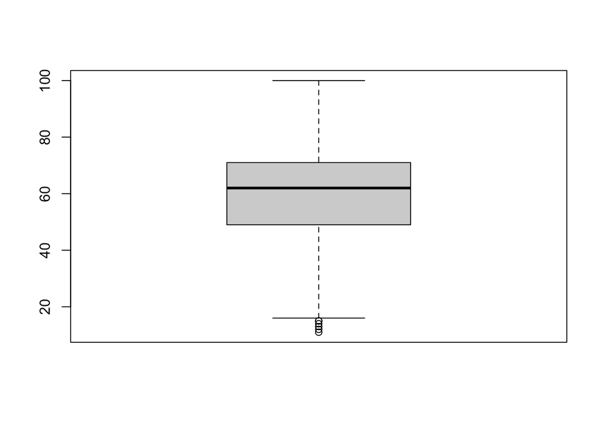

```r
boxplot(spTop_genres$Popularity)
```

```r
fivenum(spTop_genres$Popularity)
```

```
## [1]  11  49  62  71 100
```

```r
mean(spTop_genres$Popularity)
```

```
## [1] 59.52658
```

#### Categorize Popularity Value into 0 = Low and 1 = High

```r
### Set groupedPopularity as an integer value
groupedPopularity <- as.integer(ifelse(spTop_genres$Popularity > 61, "1", "0"))
popDF <- data.frame(spTop_genres, groupedPopularity)

table(groupedPopularity)  ### View groupedPopularity counts
```

```
## groupedPopularity
##    0    1
##  991 1003
```

```r
### Create gen_asInt dataframe with genres re-coded as numbers into the genreNumber variable
gen_asInt <- popDF %>% mutate(genreNumber = as.integer(case_when(genres == "adult standards" ~ '1',
                                                            genres == "rock" ~ '2',
                                                            genres == "alternative"  ~ '3',
                                                            genres == "pop" ~ '4',
                                                            genres == "dance"  ~ '5',
                                                            genres == "other" ~ '6'
                                                           )))  # end function

head(gen_asInt)  ### view gen_asInt dataframe
```

```
##   Index                                 Title            Artist
## 1     1                               Sunrise       Norah Jones
## 2     2                           Black Night       Deep Purple
## 3     3                        Clint Eastwood          Gorillaz
## 4     4                         The Pretender      Foo Fighters
## 5     5                Waitin' On A Sunny Day Bruce Springsteen
## 6     6 The Road Ahead (Miles Of The Unknown)      City To City
##                  Genre Year BPM Energy Danceability Loud_dB Liveness Valence
## 1      adult standards 2004 157     30           53     -14       11      68
## 2           album rock 2000 135     79           50     -11       17      81
## 3  alternative hip hop 2001 168     69           66      -9        7      52
## 4    alternative metal 2007 173     96           43      -4        3      37
## 5         classic rock 2002 106     82           58      -5       10      87
## 6 alternative pop rock 2004  99     46           54      -9       14      14
##   Duration Acousticness Speechiness Popularity          genres
## 1      201           94           3         71 adult standards
## 2      207           17           7         39            rock
## 3      341            2          17         69     alternative
## 4      269            0           4         76     alternative
## 5      256            1           3         59            rock
## 6      247            0           2         45     alternative
##   groupedPopularity genreNumber
## 1                 1           1
## 2                 0           2
## 3                 1           3
## 4                 1           3
## 5                 0           2
## 6                 0           3
```

#### Create dataframe with only numeric predictors and categorized response

```r
spTop_Num <- data.frame(subset(gen_asInt, select = c(-Title, -Artist, -Genre, -Popularity, -genres)))
head(spTop_Num)
```

```
##   Index Year BPM Energy Danceability Loud_dB Liveness Valence Duration
## 1     1 2004 157     30           53     -14       11      68      201
## 2     2 2000 135     79           50     -11       17      81      207
## 3     3 2001 168     69           66      -9        7      52      341
## 4     4 2007 173     96           43      -4        3      37      269
## 5     5 2002 106     82           58      -5       10      87      256
## 6     6 2004  99     46           54      -9       14      14      247
##   Acousticness Speechiness groupedPopularity genreNumber
## 1           94           3                 1           1
## 2           17           7                 0           2
## 3            2          17                 1           3
## 4            0           4                 1           3
## 5            1           3                 0           2
## 6            0           2                 0           3
```

## Full Data Set Classifications

### LDA

```r
library(MASS)
lda.fit <- lda(groupedPopularity ~ . -Index -groupedPopularity, data = spTop_Num) ### LDA model
lda.fit
```

```
## Call:
## lda(groupedPopularity ~ . - Index - groupedPopularity, data = spTop_Num)
##
## Prior probabilities of groups:
##        0        1
## 0.496991 0.503009
##
## Group means:
##       Year      BPM   Energy Danceability   Loud_dB Liveness  Valence Duration
## 0 1995.304 120.2301 57.95661     51.58224 -9.483350 20.37033 46.94046 268.2785
## 1 1990.710 120.2014 61.38185     54.87438 -8.539382 17.66999 51.84746 256.6780
##   Acousticness Speechiness genreNumber
## 0     30.53280    4.627649    3.380424
## 1     27.20339    5.357926    2.955135
##
## Coefficients of linear discriminants:
##                        LD1
## Year         -0.0414969491
## BPM           0.0006836532
## Energy       -0.0206384198
## Danceability  0.0276933642
## Loud_dB       0.2582067666
## Liveness     -0.0139112860
## Valence      -0.0016432116
## Duration     -0.0013566439
## Acousticness -0.0036542793
## Speechiness   0.0671786153
## genreNumber  -0.2560947480
```

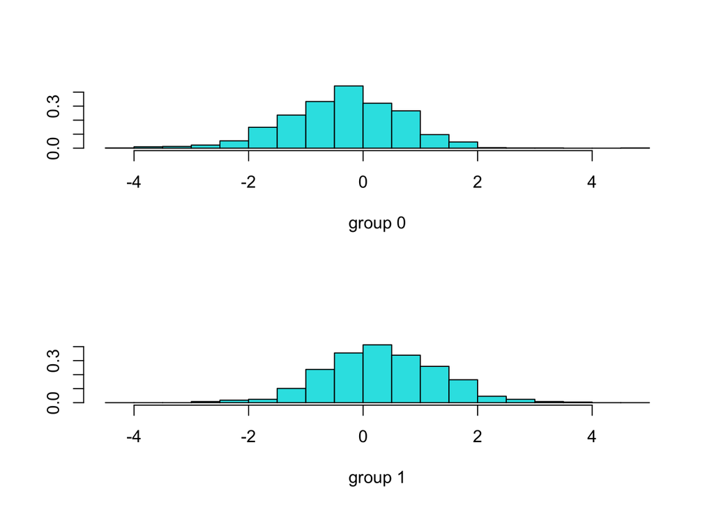

```r
plot(lda.fit)
```

```r
lda_pred = predict(lda.fit, spTop_Num) ### LDA prediction
names(lda_pred)
```

```
## [1] "class"     "posterior" "x"
```

#### All LDA code with time tracking

```r
start.time <- Sys.time()
lda.fit <- lda(groupedPopularity ~ . -Index -groupedPopularity, data = spTop_Num)
lda.fit
```

```
## Call:
## lda(groupedPopularity ~ . - Index - groupedPopularity, data = spTop_Num)
##
## Prior probabilities of groups:
##        0        1
## 0.496991 0.503009
##
## Group means:
##       Year      BPM   Energy Danceability   Loud_dB Liveness  Valence Duration
## 0 1995.304 120.2301 57.95661     51.58224 -9.483350 20.37033 46.94046 268.2785
## 1 1990.710 120.2014 61.38185     54.87438 -8.539382 17.66999 51.84746 256.6780
##   Acousticness Speechiness genreNumber
## 0     30.53280    4.627649    3.380424
## 1     27.20339    5.357926    2.955135
##
## Coefficients of linear discriminants:
##                        LD1
## Year         -0.0414969491
## BPM           0.0006836532
## Energy       -0.0206384198
## Danceability  0.0276933642
## Loud_dB       0.2582067666
## Liveness     -0.0139112860
## Valence      -0.0016432116
## Duration     -0.0013566439
## Acousticness -0.0036542793
## Speechiness   0.0671786153
## genreNumber  -0.2560947480
```

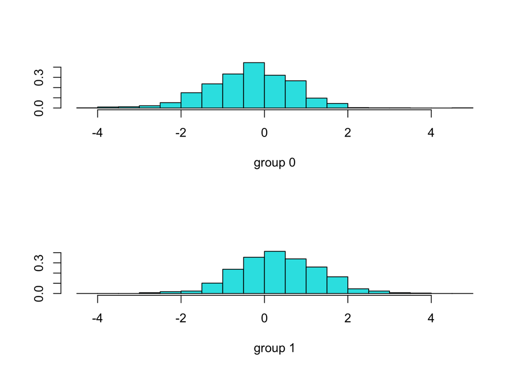

```r
plot(lda.fit)
```

```r
lda_pred = predict(lda.fit, spTop_Num)
names(lda_pred)
```

```
## [1] "class"     "posterior" "x"
```

```r
pred.lda <- predict(lda.fit, gen_asInt)
lda.conM <- table(pred.lda$class, groupedPopularity)
lda.acc <- mean(pred.lda$class == groupedPopularity)
lda.test.error = (1 - lda.acc)*100
lda.sen <- lda.conM[2,2]/(lda.conM[1,2]+lda.conM[2,2])
lda.spec <- lda.conM[1,1]/(lda.conM[1,1]+lda.conM[2,1])
end.time <- Sys.time()
time.taken <- end.time - start.time
time.taken
```

```
## Time difference of 0.01174688 secs
```

#### Print out confusion matrix, accuracy, test error, sensitivity, and specificity

```r
lda.conM
```

```
##    groupedPopularity
##       0   1
##   0 616 368
##   1 375 635
```

```r
lda.acc
```

```
## [1] 0.6273821
```

```r
lda.test.error
```

```
## [1] 37.26179
```

```r
lda.sen
```

```
## [1] 0.6331007
```

```r
lda.spec
```

```
## [1] 0.6215943
```

### QDA

```r
qda.fit <- qda(groupedPopularity ~ . -Index -groupedPopularity, data = spTop_Num)  ### QDA model
qda.fit
```

```
## Call:
## qda(groupedPopularity ~ . - Index - groupedPopularity, data = spTop_Num)
##
## Prior probabilities of groups:
##        0        1
## 0.496991 0.503009
##
## Group means:
##       Year      BPM   Energy Danceability   Loud_dB Liveness  Valence Duration
## 0 1995.304 120.2301 57.95661     51.58224 -9.483350 20.37033 46.94046 268.2785
## 1 1990.710 120.2014 61.38185     54.87438 -8.539382 17.66999 51.84746 256.6780
##   Acousticness Speechiness genreNumber
## 0     30.53280    4.627649    3.380424
## 1     27.20339    5.357926    2.955135
```

```r
qda_pred = predict(qda.fit, spTop_Num)  ### QDA predictions
names(qda_pred)
```

```
## [1] "class"     "posterior"
```

#### All QDA code with time tracking

```r
start.time <- Sys.time()
qda.fit <- qda(groupedPopularity ~ . -Index -groupedPopularity, data = spTop_Num)
qda.fit
```

```
## Call:
## qda(groupedPopularity ~ . - Index - groupedPopularity, data = spTop_Num)
##
## Prior probabilities of groups:
##        0        1
## 0.496991 0.503009
##
## Group means:
##       Year      BPM   Energy Danceability   Loud_dB Liveness  Valence Duration
## 0 1995.304 120.2301 57.95661     51.58224 -9.483350 20.37033 46.94046 268.2785
## 1 1990.710 120.2014 61.38185     54.87438 -8.539382 17.66999 51.84746 256.6780
##   Acousticness Speechiness genreNumber
## 0     30.53280    4.627649    3.380424
## 1     27.20339    5.357926    2.955135
```

```r
qda_pred = predict(qda.fit, spTop_Num)
names(qda_pred)
```

```
## [1] "class"     "posterior"
```

```r
pred.qda <- predict(qda.fit)
table(pred.qda$class, groupedPopularity)
```

```
##    groupedPopularity
##       0   1
##   0 577 287
##   1 414 716
```

```r
qda.conM <- table(pred.qda$class, groupedPopularity)
qda.acc <- mean(pred.qda$class == groupedPopularity)
qda.test.error = (1 - qda.acc)*100
qda.sen <- qda.conM[2,2]/(qda.conM[1,2]+qda.conM[2,2])
qda.spec <- qda.conM[1,1]/(qda.conM[1,1]+qda.conM[2,1])
end.time <- Sys.time()
time.taken <- end.time - start.time
time.taken
```

```
## Time difference of 0.009471893 secs
```

#### Print out confusion matrix, accuracy, test error, sensitivity, and specificity

```r
qda.conM
```

```
##    groupedPopularity
##       0   1
##   0 577 287
##   1 414 716
```

```r
qda.acc
```

```
## [1] 0.6484453
```

```r
qda.test.error
```

```
## [1] 35.15547
```

```r
qda.sen
```

```
## [1] 0.7138584
```

```r
qda.spec
```

```
## [1] 0.5822402
```

### Logistic Regression

```r
glm.fit <- glm(groupedPopularity ~ . -Index -groupedPopularity, data = spTop_Num, family = binomial())  ### Log. Reg. model
glm.fit
```

```
##
## Call:  glm(formula = groupedPopularity ~ . - Index - groupedPopularity,
##     family = binomial(), data = spTop_Num)
##
## Coefficients:
##  (Intercept)          Year           BPM        Energy  Danceability
##   58.1302825    -0.0280075     0.0004387    -0.0145726     0.0187211
##      Loud_dB      Liveness       Valence      Duration  Acousticness
##    0.1777605    -0.0099607    -0.0011016    -0.0009614    -0.0026917
##  Speechiness   genreNumber
##    0.0493070    -0.1739436
##
## Degrees of Freedom: 1993 Total (i.e. Null);  1982 Residual
## Null Deviance:       2764
## Residual Deviance: 2549  AIC: 2573
```

```r
glm.probs <- predict(glm.fit,  type = "response")
```

```r
summary(glm.fit)  ### mdoel summary
```

```
##
## Call:
## glm(formula = groupedPopularity ~ . - Index - groupedPopularity,
##     family = binomial(), data = spTop_Num)
##
## Coefficients:
##                Estimate Std. Error z value Pr(>|z|)
## (Intercept)  58.1302825  7.2313042   8.039 9.08e-16 ***
## Year         -0.0280075  0.0035821  -7.819 5.34e-15 ***
## BPM           0.0004387  0.0017603   0.249 0.803195
## Energy       -0.0145726  0.0044163  -3.300 0.000968 ***
## Danceability  0.0187211  0.0039837   4.699 2.61e-06 ***
## Loud_dB       0.1777605  0.0223119   7.967 1.62e-15 ***
## Liveness     -0.0099607  0.0030540  -3.262 0.001108 **
## Valence      -0.0011016  0.0026862  -0.410 0.681736
## Duration     -0.0009614  0.0005602  -1.716 0.086165 .
## Acousticness -0.0026917  0.0022468  -1.198 0.230918
## Speechiness   0.0493070  0.0128530   3.836 0.000125 ***
## genreNumber  -0.1739436  0.0340617  -5.107 3.28e-07 ***
## ---
## Signif. codes:  0 '***' 0.001 '**' 0.01 '*' 0.05 '.' 0.1 ' ' 1
##
## (Dispersion parameter for binomial family taken to be 1)
##
##     Null deviance: 2764.2  on 1993  degrees of freedom
## Residual deviance: 2549.4  on 1982  degrees of freedom
## AIC: 2573.4
##
## Number of Fisher Scoring iterations: 4
```

```r
glm.probs[1:10]  ### View first 10 Log. Reg. probabilities
```

```
##         1         2         3         4         5         6         7         8
## 0.3732496 0.3770306 0.6564056 0.5090484 0.6138569 0.4929563 0.5822155 0.5646525
##         9        10
## 0.5981078 0.7336529
```

#### All Logistic Regression code with time tracking

```r
start.time <- Sys.time()
glm.fit <- glm(groupedPopularity ~ . -Index -groupedPopularity, data = spTop_Num, family = binomial())  ### Log. Reg. model
glm.fit
```

```
##
## Call:  glm(formula = groupedPopularity ~ . - Index - groupedPopularity,
##     family = binomial(), data = spTop_Num)
##
## Coefficients:
##  (Intercept)          Year           BPM        Energy  Danceability
##   58.1302825    -0.0280075     0.0004387    -0.0145726     0.0187211
##      Loud_dB      Liveness       Valence      Duration  Acousticness
##    0.1777605    -0.0099607    -0.0011016    -0.0009614    -0.0026917
##  Speechiness   genreNumber
##    0.0493070    -0.1739436
##
## Degrees of Freedom: 1993 Total (i.e. Null);  1982 Residual
## Null Deviance:       2764
## Residual Deviance: 2549  AIC: 2573
```

```r
glm.probs <- predict(glm.fit,  type = "response")
glm.pred <- rep("0", 1994)
length(glm.pred)
```

```
## [1] 1994
```

```r
glm.pred[glm.probs > .5] = "1"
length(glm.pred)
```

```
## [1] 1994
```

```r
lr.conM <- table(glm.pred, groupedPopularity)
lr.acc <- mean(glm.pred == groupedPopularity)
lr.test.error = (1 - lr.acc)*100
lr.sen <- lr.conM[2,2]/(lr.conM[1,2]+lr.conM[2,2])
lr.spec <- lr.conM[1,1]/(lr.conM[1,1]+lr.conM[2,1])
end.time <- Sys.time()
time.taken <- end.time - start.time
time.taken
```

```
## Time difference of 0.009552002 secs
```

#### Print out confusion matrix, accuracy, test error, sensitivity, and specificity

```r
lr.conM
```

```
##         groupedPopularity
## glm.pred   0   1
##        0 616 369
##        1 375 634
```

```r
lr.acc
```

```
## [1] 0.6268806
```

```r
lr.test.error
```

```
## [1] 37.31194
```

```r
lr.sen
```

```
## [1] 0.6321037
```

```r
lr.spec
```

```
## [1] 0.6215943
```

### KNN

```r
library(class)
train.X <- cbind(spTop_Num$Year, spTop_Num$BPM, spTop_Num$Energy, spTop_Num$Danceability, spTop_Num$Loud_dB, spTop_Num$Liveness, spTop_Num$Valence, spTop_Num$Duration, spTop_Num$Acousticness, spTop_Num$Speechiness, spTop_Num$genreNumber)
test.X <- cbind(spTop_Num$Year, spTop_Num$BPM, spTop_Num$Energy, spTop_Num$Danceability, spTop_Num$Loud_dB, spTop_Num$Liveness, spTop_Num$Valence, spTop_Num$Duration, spTop_Num$Acousticness, spTop_Num$Speechiness, spTop_Num$genreNumber)
train.pop <- groupedPopularity
```

#### Set Seed and Run K = 1 model

```r
set.seed(12)
start.time <- Sys.time()
knn.pred1 <- knn(train.X, test.X, train.pop, k = 1)
knn1.conM <- table(knn.pred1, groupedPopularity)
knn1.acc <- mean(knn.pred1 == groupedPopularity)
knn1.test.error = (1 - knn1.acc)*100
knn1.sen <- knn1.conM[2,2]/(knn1.conM[1,2]+knn1.conM[2,2])
knn1.spec <- knn1.conM[1,1]/(knn1.conM[1,1]+knn1.conM[2,1])
end.time <- Sys.time()
time.taken <- end.time - start.time
time.taken
```

```
## Time difference of 0.0198071 secs
```

#### Print out confusion matrix, accuracy, test error, sensitivity, and specificity

```r
knn1.conM
```

```
##          groupedPopularity
## knn.pred1    0    1
##         0  991    0
##         1    0 1003
```

```r
knn1.acc
```

```
## [1] 1
```

```r
knn1.test.error
```

```
## [1] 0
```

```r
knn1.sen
```

```
## [1] 1
```

```r
knn1.spec
```

```
## [1] 1
```

#### K = 3

```r
set.seed(12)
start.time <- Sys.time()
knn.pred3 <- knn(train.X, test.X, train.pop, k = 3)
knn3.conM <- table(knn.pred3, groupedPopularity)
knn3.acc <- mean(knn.pred3 == groupedPopularity)
knn3.test.error = (1 - knn3.acc)*100
knn3.sen <- knn3.conM[2,2]/(knn3.conM[1,2]+knn3.conM[2,2])
knn3.spec <- knn3.conM[1,1]/(knn3.conM[1,1]+knn3.conM[2,1])
end.time <- Sys.time()
time.taken <- end.time - start.time
time.taken
```

```
## Time difference of 0.01995087 secs
```

#### Print out confusion matrix, accuracy, test error, sensitivity, and specificity

```r
knn3.conM
```

```
##          groupedPopularity
## knn.pred3   0   1
##         0 770 223
##         1 221 780
```

```r
knn3.acc
```

```
## [1] 0.777332
```

```r
knn3.test.error
```

```
## [1] 22.2668
```

```r
knn3.sen
```

```
## [1] 0.777667
```

```r
knn3.spec
```

```
## [1] 0.7769929
```

### k = 5

```r
set.seed(12)
start.time <- Sys.time()
knn.pred5 <- knn(train.X, test.X, train.pop, k = 5)
knn5.conM <- table(knn.pred5, groupedPopularity)
knn5.acc <- mean(knn.pred5 == groupedPopularity)
knn5.test.error = (1 - knn5.acc)*100
knn5.sen <- knn5.conM[2,2]/(knn5.conM[1,2]+knn5.conM[2,2])
knn5.spec <- knn5.conM[1,1]/(knn5.conM[1,1]+knn5.conM[2,1])
end.time <- Sys.time()
time.taken <- end.time - start.time
time.taken
```

```
## Time difference of 0.02103996 secs
```

#### Print out confusion matrix, accuracy, test error, sensitivity, and specificity

```r
knn5.conM
```

```
##          groupedPopularity
## knn.pred5   0   1
##         0 720 292
##         1 271 711
```

```r
knn5.acc
```

```
## [1] 0.717653
```

```r
knn5.test.error
```

```
## [1] 28.2347
```

```r
knn5.sen
```

```
## [1] 0.7088734
```

```r
knn5.spec
```

```
## [1] 0.7265388
```

### k = 8

```r
set.seed(12)
start.time <- Sys.time()
knn.pred8 <- knn(train.X, test.X, train.pop, k = 8)
knn8.conM <- table(knn.pred8, groupedPopularity)
knn8.acc <- mean(knn.pred8 == groupedPopularity)
knn8.test.error = (1 - knn8.acc)*100
knn8.sen <- knn8.conM[2,2]/(knn8.conM[1,2]+knn8.conM[2,2])
knn8.spec <- knn8.conM[1,1]/(knn8.conM[1,1]+knn8.conM[2,1])
end.time <- Sys.time()
time.taken <- end.time - start.time
time.taken
```

```
## Time difference of 0.02219486 secs
```

#### Print out confusion matrix, accuracy, test error, sensitivity, and specificity

```r
knn8.conM
```

```
##          groupedPopularity
## knn.pred8   0   1
##         0 691 339
##         1 300 664
```

```r
knn8.acc
```

```
## [1] 0.6795386
```

```r
knn8.test.error
```

```
## [1] 32.04614
```

```r
knn8.sen
```

```
## [1] 0.662014
```

```r
knn8.spec
```

```
## [1] 0.6972755
```

### k = 10

```r
set.seed(12)
start.time <- Sys.time()
knn.pred10 <- knn(train.X, test.X, train.pop, k = 10)
knn10.conM <- table(knn.pred10, groupedPopularity)
knn10.acc <- mean(knn.pred10 == groupedPopularity)
knn10.test.error = (1 - knn10.acc)*100
knn10.sen <- knn10.conM[2,2]/(knn10.conM[1,2]+knn10.conM[2,2])
knn10.spec <- knn10.conM[1,1]/(knn10.conM[1,1]+knn10.conM[2,1])
end.time <- Sys.time()
time.taken <- end.time - start.time
time.taken
```

```
## Time difference of 0.02507281 secs
```

#### Print out confusion matrix, accuracy, test error, sensitivity, and specificity

```r
knn10.conM
```

```
##           groupedPopularity
## knn.pred10   0   1
##          0 672 349
##          1 319 654
```

```r
knn10.acc
```

```
## [1] 0.664995
```

```r
knn10.test.error
```

```
## [1] 33.5005
```

```r
knn10.sen
```

```
## [1] 0.6520439
```

```r
knn10.spec
```

```
## [1] 0.6781029
```

## Classification on 50% Data

### Spliting the data into Training and Testing Data

```r
dim(spTop_Num)
```

```
## [1] 1994   13
```

```r
set.seed(12)
train <- (spTop_Num$Index < 998)
test <- spTop_Num[!train, ]
### Verify dimension of training and testing data
dim(test)
```

```
## [1] 997  13
```

```r
### Verify seeding and split data sets
head(test)
```

```
##      Index Year BPM Energy Danceability Loud_dB Liveness Valence Duration
## 998    998 1975 125     76           84      -5        3      60      251
## 999    999 1975  37     25           27     -12        9      13      207
## 1000  1000 1976 147     51           58      -9        6      61      391
## 1001  1001 1976 112     69           50      -7       22      36      296
## 1002  1002 1976 101     88           54      -7       76      75      231
## 1003  1003 1976 126     28           55     -11       16      30      445
##      Acousticness Speechiness groupedPopularity genreNumber
## 998             6           9                 0           2
## 999            80           4                 0           2
## 1000            1           3                 1           2
## 1001           19           6                 1           2
## 1002           38           4                 1           4
## 1003           47           3                 0           2
```

```r
popTest <- groupedPopularity[!train]
```

### LDA

```r
library(MASS)
lda.fit <- lda(groupedPopularity ~ . -Index -groupedPopularity, data = spTop_Num, subset = train)
lda.fit
```

```
## Call:
## lda(groupedPopularity ~ . - Index - groupedPopularity, data = spTop_Num,
##     subset = train)
##
## Prior probabilities of groups:
##         0         1
## 0.5155466 0.4844534
##
## Group means:
##       Year      BPM   Energy Danceability   Loud_dB Liveness  Valence Duration
## 0 2004.220 121.3093 59.56420     50.63813 -8.626459 21.11868 45.14591 261.4630
## 1 2000.027 121.1760 61.44513     55.48861 -7.805383 17.33333 48.20911 254.3499
##   Acousticness Speechiness genreNumber
## 0     30.31907    4.692607    3.566148
## 1     28.15114    5.670807    3.118012
##
## Coefficients of linear discriminants:
##                        LD1
## Year         -0.0428743504
## BPM           0.0009747596
## Energy       -0.0272158116
## Danceability  0.0422100511
## Loud_dB       0.2930675728
## Liveness     -0.0129853387
## Valence      -0.0063119843
## Duration     -0.0004798636
## Acousticness -0.0018088511
## Speechiness   0.0730660382
## genreNumber  -0.2646227572
```

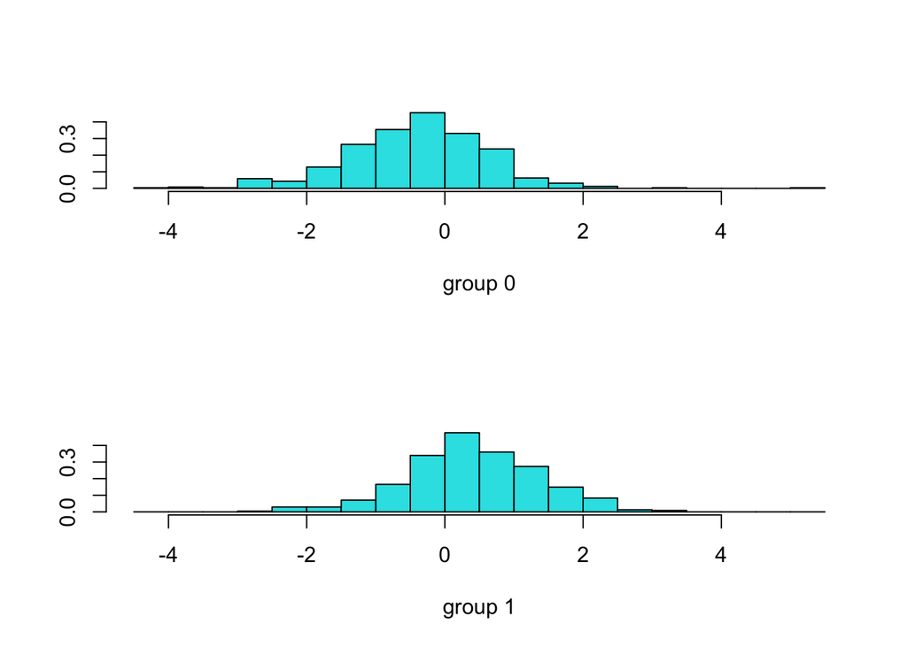

```r
plot(lda.fit)
```

```r
lda_pred = predict(lda.fit, test)
names(lda_pred)
```

```
## [1] "class"     "posterior" "x"
```

#### All LDA code with time tracking - 50% data

```r
start.time <- Sys.time()
lda50.fit <- lda(groupedPopularity ~ . -Index -groupedPopularity, data = spTop_Num, subset = train)
lda50.fit
```

```
## Call:
## lda(groupedPopularity ~ . - Index - groupedPopularity, data = spTop_Num,
##     subset = train)
##
## Prior probabilities of groups:
##         0         1
## 0.5155466 0.4844534
##
## Group means:
##       Year      BPM   Energy Danceability   Loud_dB Liveness  Valence Duration
## 0 2004.220 121.3093 59.56420     50.63813 -8.626459 21.11868 45.14591 261.4630
## 1 2000.027 121.1760 61.44513     55.48861 -7.805383 17.33333 48.20911 254.3499
##   Acousticness Speechiness genreNumber
## 0     30.31907    4.692607    3.566148
## 1     28.15114    5.670807    3.118012
##
## Coefficients of linear discriminants:
##                        LD1
## Year         -0.0428743504
## BPM           0.0009747596
## Energy       -0.0272158116
## Danceability  0.0422100511
## Loud_dB       0.2930675728
## Liveness     -0.0129853387
## Valence      -0.0063119843
## Duration     -0.0004798636
## Acousticness -0.0018088511
## Speechiness   0.0730660382
## genreNumber  -0.2646227572
```

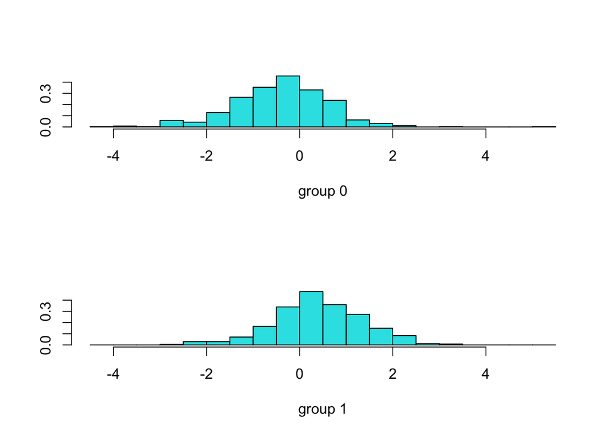

```r
plot(lda50.fit)
```

```r
lda_pred50 = predict(lda50.fit, test)
names(lda_pred50)
```

```
## [1] "class"     "posterior" "x"
```

```r
pred.lda50 <- predict(lda50.fit, test)
lda50.conM <- table(pred.lda50$class, popTest)
lda50.acc <- mean(pred.lda50$class == popTest)
lda50.test.error = (1 - lda50.acc)*100
lda50.sen <- lda50.conM[2,2]/(lda50.conM[1,2]+lda50.conM[2,2])
lda50.spec <- lda50.conM[1,1]/(lda50.conM[1,1]+lda50.conM[2,1])
end.time <- Sys.time()
time.taken <- end.time - start.time
time.taken
```

```
## Time difference of 0.009008884 secs
```

#### Print out confusion matrix, accuracy, test error, sensitivity, and specificity

```r
lda50.conM
```

```
##    popTest
##       0   1
##   0 218 157
##   1 259 363
```

```r
lda50.acc
```

```
## [1] 0.5827482
```

```r
lda50.test.error
```

```
## [1] 41.72518
```

```r
lda50.sen
```

```
## [1] 0.6980769
```

```r
lda50.spec
```

```
## [1] 0.4570231
```

### QDA

```r
qda.fit <- qda(groupedPopularity ~ . -Index -groupedPopularity, data = spTop_Num, subset = train)
qda.fit
```

```
## Call:
## qda(groupedPopularity ~ . - Index - groupedPopularity, data = spTop_Num,
##     subset = train)
##
## Prior probabilities of groups:
##         0         1
## 0.5155466 0.4844534
##
## Group means:
##       Year      BPM   Energy Danceability   Loud_dB Liveness  Valence Duration
## 0 2004.220 121.3093 59.56420     50.63813 -8.626459 21.11868 45.14591 261.4630
## 1 2000.027 121.1760 61.44513     55.48861 -7.805383 17.33333 48.20911 254.3499
##   Acousticness Speechiness genreNumber
## 0     30.31907    4.692607    3.566148
## 1     28.15114    5.670807    3.118012
```

```r
qda_pred = predict(qda.fit, test)
names(qda_pred)
```

```
## [1] "class"     "posterior"
```

#### All QDA code with time tracking - 50% data

```r
start.time <- Sys.time()
qda50.fit <- qda(groupedPopularity ~ . -Index -groupedPopularity, data = spTop_Num, subset = train)
qda50.fit
```

```
## Call:
## qda(groupedPopularity ~ . - Index - groupedPopularity, data = spTop_Num,
##     subset = train)
##
## Prior probabilities of groups:
##         0         1
## 0.5155466 0.4844534
##
## Group means:
##       Year      BPM   Energy Danceability   Loud_dB Liveness  Valence Duration
## 0 2004.220 121.3093 59.56420     50.63813 -8.626459 21.11868 45.14591 261.4630
## 1 2000.027 121.1760 61.44513     55.48861 -7.805383 17.33333 48.20911 254.3499
##   Acousticness Speechiness genreNumber
## 0     30.31907    4.692607    3.566148
## 1     28.15114    5.670807    3.118012
```

```r
qda_pred50 = predict(qda50.fit, test)
names(qda_pred50)
```

```
## [1] "class"     "posterior"
```

```r
pred.qda50 <- predict(qda50.fit, test)
qda50.conM <- table(pred.qda50$class, popTest)
qda50.acc <- mean(pred.qda50$class == popTest)
qda50.test.error = (1 - qda50.acc)*100
qda50.sen <- qda50.conM[2,2]/(qda50.conM[1,2]+qda50.conM[2,2])
qda50.spec <- qda50.conM[1,1]/(qda50.conM[1,1]+qda50.conM[2,1])
end.time <- Sys.time()
time.taken <- end.time - start.time
time.taken
```

```
## Time difference of 0.006413937 secs
```

#### Print out confusion matrix, accuracy, test error, sensitivity, and specificity

```r
qda50.conM
```

```
##    popTest
##       0   1
##   0 201 125
##   1 276 395
```

```r
qda50.acc
```

```
## [1] 0.5977934
```

```r
qda50.test.error
```

```
## [1] 40.22066
```

```r
qda50.sen
```

```
## [1] 0.7596154
```

```r
qda50.spec
```

```
## [1] 0.4213836
```

### Logistic Regression

```r
glm.fit <- glm(groupedPopularity ~ . -Index -groupedPopularity, data = spTop_Num, family = binomial())
glm.fit
```

```
##
## Call:  glm(formula = groupedPopularity ~ . - Index - groupedPopularity,
##     family = binomial(), data = spTop_Num)
##
## Coefficients:
##  (Intercept)          Year           BPM        Energy  Danceability
##   58.1302825    -0.0280075     0.0004387    -0.0145726     0.0187211
##      Loud_dB      Liveness       Valence      Duration  Acousticness
##    0.1777605    -0.0099607    -0.0011016    -0.0009614    -0.0026917
##  Speechiness   genreNumber
##    0.0493070    -0.1739436
##
## Degrees of Freedom: 1993 Total (i.e. Null);  1982 Residual
## Null Deviance:       2764
## Residual Deviance: 2549  AIC: 2573
```

```r
glm.probs <- predict(glm.fit,  type = "response")
```

```r
summary(glm.fit)
```

```
##
## Call:
## glm(formula = groupedPopularity ~ . - Index - groupedPopularity,
##     family = binomial(), data = spTop_Num)
##
## Coefficients:
##                Estimate Std. Error z value Pr(>|z|)
## (Intercept)  58.1302825  7.2313042   8.039 9.08e-16 ***
## Year         -0.0280075  0.0035821  -7.819 5.34e-15 ***
## BPM           0.0004387  0.0017603   0.249 0.803195
## Energy       -0.0145726  0.0044163  -3.300 0.000968 ***
## Danceability  0.0187211  0.0039837   4.699 2.61e-06 ***
## Loud_dB       0.1777605  0.0223119   7.967 1.62e-15 ***
## Liveness     -0.0099607  0.0030540  -3.262 0.001108 **
## Valence      -0.0011016  0.0026862  -0.410 0.681736
## Duration     -0.0009614  0.0005602  -1.716 0.086165 .
## Acousticness -0.0026917  0.0022468  -1.198 0.230918
## Speechiness   0.0493070  0.0128530   3.836 0.000125 ***
## genreNumber  -0.1739436  0.0340617  -5.107 3.28e-07 ***
## ---
## Signif. codes:  0 '***' 0.001 '**' 0.01 '*' 0.05 '.' 0.1 ' ' 1
##
## (Dispersion parameter for binomial family taken to be 1)
##
##     Null deviance: 2764.2  on 1993  degrees of freedom
## Residual deviance: 2549.4  on 1982  degrees of freedom
## AIC: 2573.4
##
## Number of Fisher Scoring iterations: 4
```

```r
glm.probs[1:10]
```

```
##         1         2         3         4         5         6         7         8
## 0.3732496 0.3770306 0.6564056 0.5090484 0.6138569 0.4929563 0.5822155 0.5646525
##         9        10
## 0.5981078 0.7336529
```

#### All Logistic Regression Code with Time Tracking - 50% data

```r
start.time <- Sys.time()
glm50.fit <- glm(groupedPopularity ~ . -Index -groupedPopularity, data = spTop_Num, family = binomial())  ### Log. Reg. model
glm50.fit
```

```
##
## Call:  glm(formula = groupedPopularity ~ . - Index - groupedPopularity,
##     family = binomial(), data = spTop_Num)
##
## Coefficients:
##  (Intercept)          Year           BPM        Energy  Danceability
##   58.1302825    -0.0280075     0.0004387    -0.0145726     0.0187211
##      Loud_dB      Liveness       Valence      Duration  Acousticness
##    0.1777605    -0.0099607    -0.0011016    -0.0009614    -0.0026917
##  Speechiness   genreNumber
##    0.0493070    -0.1739436
##
## Degrees of Freedom: 1993 Total (i.e. Null);  1982 Residual
## Null Deviance:       2764
## Residual Deviance: 2549  AIC: 2573
```

```r
glm50.probs <- predict(glm50.fit,  type = "response")
glm50.pred=predict(glm50.fit, test[ , c("Index", "Year", "BPM", "Energy", "Danceability", "Loud_dB", "Liveness", "Valence", "Duration", "Acousticness", "Speechiness", "genreNumber")], n.pop = 997, type = "response")
glm50.pred <- factor(ifelse(glm50.pred<=0.5, 0, 1))
length(glm50.pred)  ### check length, is it the correct number of data points
```

```
## [1] 997
```

```r
lr50.conM <- table(glm50.pred, popTest)
lr50.acc <- mean(glm50.pred == popTest)
lr50.test.error = (1 - lr50.acc)*100
lr50.sen <- lr50.conM[2,2]/(lr50.conM[1,2]+lr50.conM[2,2])
lr50.spec <- lr50.conM[1,1]/(lr50.conM[1,1]+lr50.conM[2,1])
end.time <- Sys.time()
time.taken <- end.time - start.time
time.taken
```

```
## Time difference of 0.007600069 secs
```

#### Print out confusion matrix, accuracy, test error, sensitivity, and specificity

```r
lr50.conM
```

```
##           popTest
## glm50.pred   0   1
##          0 237 168
##          1 240 352
```

```r
lr50.acc
```

```
## [1] 0.5907723
```

```r
lr50.test.error
```

```
## [1] 40.92277
```

```r
lr50.sen
```

```
## [1] 0.6769231
```

```r
lr50.spec
```

```
## [1] 0.4968553
```

### KNN

```r
library(class)
train.X50 <- cbind(spTop_Num$Year, spTop_Num$BPM, spTop_Num$Energy, spTop_Num$Danceability, spTop_Num$Loud_dB, spTop_Num$Liveness, spTop_Num$Valence, spTop_Num$Duration, spTop_Num$Acousticness, spTop_Num$Speechiness, spTop_Num$genreNumber)[train, ]
test.X50 <- cbind(spTop_Num$Year, spTop_Num$BPM, spTop_Num$Energy, spTop_Num$Danceability, spTop_Num$Loud_dB, spTop_Num$Liveness, spTop_Num$Valence, spTop_Num$Duration, spTop_Num$Acousticness, spTop_Num$Speechiness, spTop_Num$genreNumber)[!train, ]
train.pop50 <- groupedPopularity[train]
```

#### Set Seed and Run K = 1 model

```r
set.seed(12)
start.time <- Sys.time()
knn1.pred50 <- knn(train.X50, test.X50, train.pop50, k = 1)
knn1.conM50 <- table(knn1.pred50, popTest)
knn1.acc50 <- mean(knn1.pred50 == popTest)
knn1.test.error50 = (1 - knn1.acc50)*100
knn1.sen50 <- knn1.conM50[2,2]/(knn1.conM50[1,2]+knn1.conM50[2,2])
knn1.spec50 <- knn1.conM50[1,1]/(knn1.conM50[1,1]+knn1.conM50[2,1])
end.time <- Sys.time()
time.taken <- end.time - start.time
time.taken
```

```
## Time difference of 0.006397963 secs
```

#### Print out confusion matrix, accuracy, test error, sensitivity, and specificity

```r
knn1.conM50
```

```
##            popTest
## knn1.pred50   0   1
##           0 247 244
##           1 230 276
```

```r
knn1.acc50
```

```
## [1] 0.5245737
```

```r
knn1.test.error50
```

```
## [1] 47.54263
```

```r
knn1.sen50
```

```
## [1] 0.5307692
```

```r
knn1.spec50
```

```
## [1] 0.5178197
```

#### Set Seed and Run K = 3 model

```r
set.seed(12)
start.time <- Sys.time()
knn3.pred50 <- knn(train.X50, test.X50, train.pop50, k = 3)
knn3.conM50 <- table(knn3.pred50, popTest)
knn3.acc50 <- mean(knn3.pred50 == popTest)
knn3.test.error50 = (1 - knn3.acc50)*100
knn3.sen50 <- knn3.conM50[2,2]/(knn3.conM50[1,2]+knn3.conM50[2,2])
knn3.spec50 <- knn3.conM50[1,1]/(knn3.conM50[1,1]+knn3.conM50[2,1])
end.time <- Sys.time()
time.taken <- end.time - start.time
time.taken
```

```
## Time difference of 0.006669044 secs
```

#### Print out confusion matrix, accuracy, test error, sensitivity, and specificity

```r
knn3.conM50
```

```
##            popTest
## knn3.pred50   0   1
##           0 234 228
##           1 243 292
```

```r
knn3.acc50
```

```
## [1] 0.5275827
```

```r
knn3.test.error50
```

```
## [1] 47.24173
```

```r
knn3.sen50
```

```
## [1] 0.5615385
```

```r
knn3.spec50
```

```
## [1] 0.490566
```

#### Set Seed and Run K = 5 model

```r
set.seed(12)
start.time <- Sys.time()
knn5.pred50 <- knn(train.X50, test.X50, train.pop50, k = 5)
knn5.conM50 <- table(knn5.pred50, popTest)
knn5.acc50 <- mean(knn5.pred50 == popTest)
knn5.test.error50 = (1 - knn5.acc50)*100
knn5.sen50 <- knn5.conM50[2,2]/(knn5.conM50[1,2]+knn5.conM50[2,2])
knn5.spec50 <- knn5.conM50[1,1]/(knn5.conM50[1,1]+knn5.conM50[2,1])
end.time <- Sys.time()
time.taken <- end.time - start.time
time.taken
```

```
## Time difference of 0.007009983 secs
```

#### Print out confusion matrix, accuracy, test error, sensitivity, and specificity

```r
knn5.conM50
```

```
##            popTest
## knn5.pred50   0   1
##           0 241 231
##           1 236 289
```

```r
knn5.acc50
```

```
## [1] 0.5315948
```

```r
knn5.test.error50
```

```
## [1] 46.84052
```

```r
knn5.sen50
```

```
## [1] 0.5557692
```

```r
knn5.spec50
```

```
## [1] 0.5052411
```

#### Set Seed and Run K = 8 model

```r
set.seed(12)
start.time <- Sys.time()
knn8.pred50 <- knn(train.X50, test.X50, train.pop50, k = 8)
knn8.conM50 <- table(knn8.pred50, popTest)
knn8.acc50 <- mean(knn8.pred50 == popTest)
knn8.test.error50 = (1 - knn8.acc50)*100
knn8.sen50 <- knn8.conM50[2,2]/(knn8.conM50[1,2]+knn8.conM50[2,2])
knn8.spec50 <- knn8.conM50[1,1]/(knn8.conM50[1,1]+knn8.conM50[2,1])
end.time <- Sys.time()
time.taken <- end.time - start.time
time.taken
```

```
## Time difference of 0.007338047 secs
```

#### Print out confusion matrix, accuracy, test error, sensitivity, and specificity

```r
knn8.conM50
```

```
##            popTest
## knn8.pred50   0   1
##           0 236 213
##           1 241 307
```

```r
knn8.acc50
```

```
## [1] 0.5446339
```

```r
knn8.test.error50
```

```
## [1] 45.53661
```

```r
knn8.sen50
```

```
## [1] 0.5903846
```

```r
knn8.spec50
```

```
## [1] 0.4947589
```

#### Set Seed and Run K = 10 model

```r
set.seed(12)
start.time <- Sys.time()
knn10.pred50 <- knn(train.X50, test.X50, train.pop50, k = 10)
knn10.conM50 <- table(knn10.pred50, popTest)
knn10.acc50 <- mean(knn10.pred50 == popTest)
knn10.test.error50 = (1 - knn10.acc50)*100
knn10.sen50 <- knn10.conM50[2,2]/(knn10.conM50[1,2]+knn10.conM50[2,2])
knn10.spec50 <- knn10.conM50[1,1]/(knn10.conM50[1,1]+knn10.conM50[2,1])
end.time <- Sys.time()
time.taken <- end.time - start.time
time.taken
```

```
## Time difference of 0.007790089 secs
```

#### Print out confusion matrix, accuracy, test error, sensitivity, and specificity

```r
knn10.conM50
```

```
##             popTest
## knn10.pred50   0   1
##            0 234 222
##            1 243 298
```

```r
knn10.acc50
```

```
## [1] 0.5336008
```

```r
knn10.test.error50
```

```
## [1] 46.63992
```

```r
knn10.sen50
```

```
## [1] 0.5730769
```

```r
knn10.spec50
```

```
## [1] 0.490566
```

### Visualizations

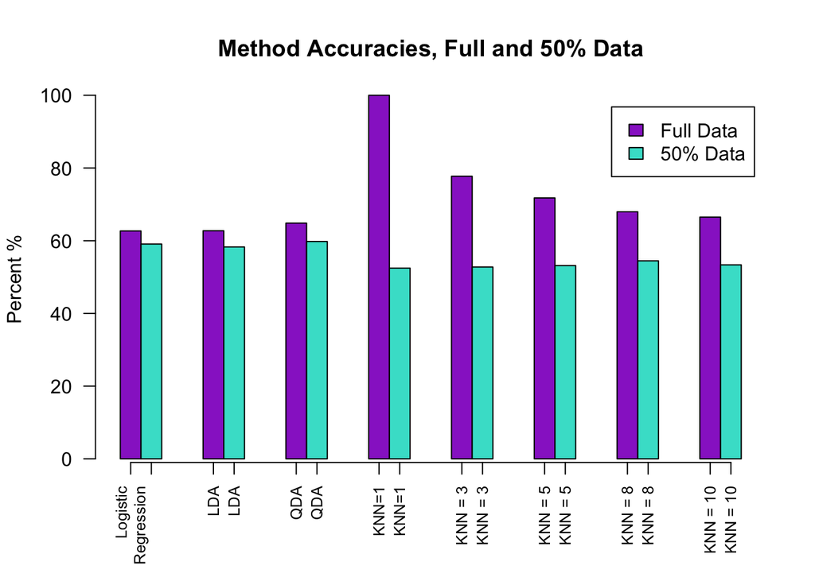

```r
accuracy <- c(lr.acc*100, lr50.acc*100, lda.acc*100, lda50.acc*100, qda.acc*100, qda50.acc*100, knn1.acc*100, knn1.acc50*100, knn3.acc*100, knn3.acc50*100, knn5.acc*100, knn5.acc50*100, knn8.acc*100, knn8.acc50*100, knn10.acc*100, knn10.acc50*100)
barplot(accuracy, main = "Method Accuracies, Full and 50% Data", names.arg=c("Logistic\n Regression", "Logistic\n Regression", "LDA", "LDA", "QDA", "QDA", "KNN=1", "KNN=1", "KNN = 3", "KNN = 3", "KNN = 5", "KNN = 5", "KNN = 8", "KNN = 8", "KNN = 10", "KNN = 10"), ylab = "Percent %", cex.names = 0.8, las = 2, space = c(0, 0, 2, 0, 2, 0, 2, 0, 2, 0, 2, 0, 2, 0, 2, 0), col = c("#9932cc", "#40e0d0"), legend=c("Full Data","50% Data"),axis.lty=1, )
```

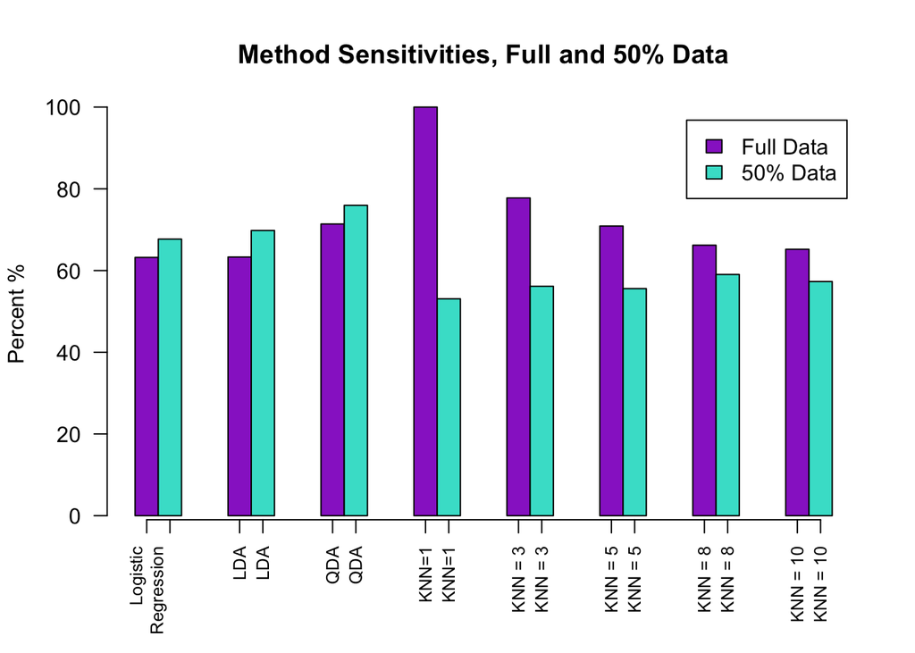

```r
sensitivity <- c(lr.sen*100, lr50.sen*100, lda.sen*100, lda50.sen*100, qda.sen*100, qda50.sen*100, knn1.sen*100, knn1.sen50*100, knn3.sen*100, knn3.sen50*100, knn5.sen*100, knn5.sen50*100, knn8.sen*100, knn8.sen50*100, knn10.sen*100, knn10.sen50*100)
barplot(sensitivity, main = "Method Sensitivities, Full and 50% Data", names.arg=c("Logistic\n Regression", "Logistic\n Regression", "LDA", "LDA", "QDA", "QDA", "KNN=1", "KNN=1", "KNN = 3", "KNN = 3", "KNN = 5", "KNN = 5", "KNN = 8", "KNN = 8", "KNN = 10", "KNN = 10"), ylab = "Percent %", cex.names = 0.8, las = 2, space = c(0, 0, 2, 0, 2, 0, 2, 0, 2, 0, 2, 0, 2, 0, 2, 0), col = c("#9932cc", "#40e0d0"), legend=c("Full Data","50% Data"),axis.lty=1, )
```

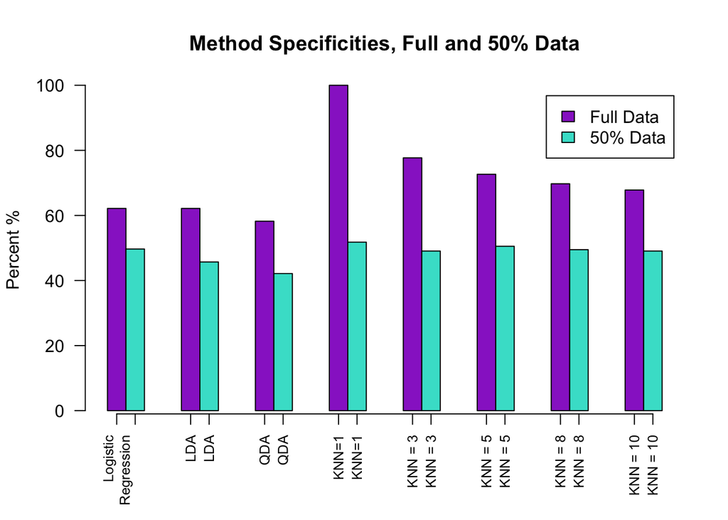

```r
specificity <- c(lr.spec*100, lr50.spec*100, lda.spec*100, lda50.spec*100, qda.spec*100, qda50.spec*100, knn1.spec*100, knn1.spec50*100, knn3.spec*100, knn3.spec50*100, knn5.spec*100, knn5.spec50*100, knn8.spec*100, knn8.spec50*100, knn10.spec*100, knn10.spec50*100)
barplot(specificity, main = "Method Specificities, Full and 50% Data", names.arg=c("Logistic\n Regression", "Logistic\n Regression", "LDA", "LDA", "QDA", "QDA", "KNN=1", "KNN=1", "KNN = 3", "KNN = 3", "KNN = 5", "KNN = 5", "KNN = 8", "KNN = 8", "KNN = 10", "KNN = 10"), ylab = "Percent %", cex.names = 0.8, las = 2, space = c(0, 0, 2, 0, 2, 0, 2, 0, 2, 0, 2, 0, 2, 0, 2, 0), col = c("#9932cc", "#40e0d0"), legend=c("Full Data","50% Data"),axis.lty=1, )
```

## Decision Tree, Bagging, and Random Forest

### Create training and test sets

```r
dim(spTop_Num)
```

```
## [1] 1994   13
```

```r
set.seed(12)
train <- (spTop_Num$Index <= 997)
top.test <- spTop_Num[-train, ]
pop.test <- groupedPopularity[-train]
### Verify dimension of training and testing data
dim(test)
```

```
## [1] 997  13
```

```r
length(train)
```

```
## [1] 1994
```

```r
### Verify seeding and split data sets
head(test)
```

```
##      Index Year BPM Energy Danceability Loud_dB Liveness Valence Duration
## 998    998 1975 125     76           84      -5        3      60      251
## 999    999 1975  37     25           27     -12        9      13      207
## 1000  1000 1976 147     51           58      -9        6      61      391
## 1001  1001 1976 112     69           50      -7       22      36      296
## 1002  1002 1976 101     88           54      -7       76      75      231
## 1003  1003 1976 126     28           55     -11       16      30      445
##      Acousticness Speechiness groupedPopularity genreNumber
## 998             6           9                 0           2
## 999            80           4                 0           2
## 1000            1           3                 1           2
## 1001           19           6                 1           2
## 1002           38           4                 1           4
## 1003           47           3                 0           2
```

```r
length(top.test)
```

```
## [1] 13
```

```r
length(pop.test)
```

```
## [1] 1993
```

```r
popTest <- groupedPopularity[!train]
```

### Decision Tree

```r
library(tree)

start.time <- Sys.time()
tree.pop <- tree(factor(groupedPopularity) ~ . -Index -groupedPopularity, data = spTop_Num)
summary(tree.pop)
```

```
##
## Classification tree:
## tree(formula = factor(groupedPopularity) ~ . - Index - groupedPopularity,
##     data = spTop_Num)
## Variables actually used in tree construction:
## [1] "Year"    "Loud_dB"
## Number of terminal nodes:  3
## Residual mean deviance:  1.334 = 2656 / 1991
## Misclassification error rate: 0.3907 = 779 / 1994
```

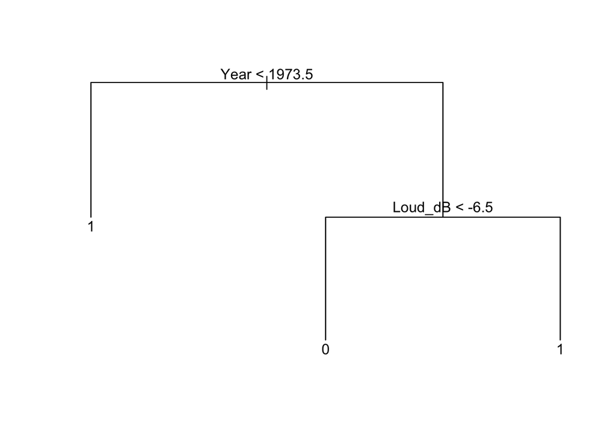

```r
plot(tree.pop)
text(tree.pop, pretty = 0)
```

```r
end.time <- Sys.time()
time.taken <- end.time - start.time
time.taken
```

```
## Time difference of 0.008508921 secs
```

```r
tree.pop
```

```
## node), split, n, deviance, yval, (yprob)
##       * denotes terminal node
##
## 1) root 1994 2764.0 1 ( 0.4970 0.5030 )
##   2) Year < 1973.5 308  377.3 1 ( 0.3019 0.6981 ) *
##   3) Year > 1973.5 1686 2330.0 0 ( 0.5326 0.4674 )
##     6) Loud_dB < -6.5 1170 1583.0 0 ( 0.5906 0.4094 ) *
##     7) Loud_dB > -6.5 516  695.0 1 ( 0.4012 0.5988 ) *
```

```r
start.time <- Sys.time()
tree.pop <- tree(factor(groupedPopularity) ~ . -Index -groupedPopularity, data = spTop_Num, subset = train)
tree.pred <- predict(tree.pop, top.test, type = "class")
table(tree.pred, pop.test)
```

```
##          pop.test
## tree.pred   0   1
##         0 635 438
##         1 356 564
```

```r
end.time <- Sys.time()
time.taken <- end.time - start.time
time.taken
```

```
## Time difference of 0.012954 secs
```

```r
acc.DT <- (635 + 564)/(635 + 438 + 356 + 564)  ## accuracy
acc.DT
```

```
## [1] 0.6016056
```

```r
se.DT <- 1 - acc.DT
se.DT
```

```
## [1] 0.3983944
```

```r
sen.DT <- 564/(438 + 564)  ## sensitivity
sen.DT
```

```
## [1] 0.5628743
```

```r
spec.DT <- 635/(635 + 356)  ## specificity
spec.DT
```

```
## [1] 0.6407669
```

```r
set.seed(12)
cv.topPop <- cv.tree(tree.pop, FUN = prune.misclass)
names(cv.topPop)
```

```
## [1] "size"   "dev"    "k"      "method"
```

```r
cv.topPop
```

```
## $size
## [1] 8 7 5 4 3 2 1
##
## $dev
## [1] 444 444 446 446 443 484 484
##
## $k
## [1] -Inf  0.0  5.5  6.0  8.0 52.0 53.0
##
## $method
## [1] "misclass"
##
## attr(,"class")
## [1] "prune"         "tree.sequence"
```

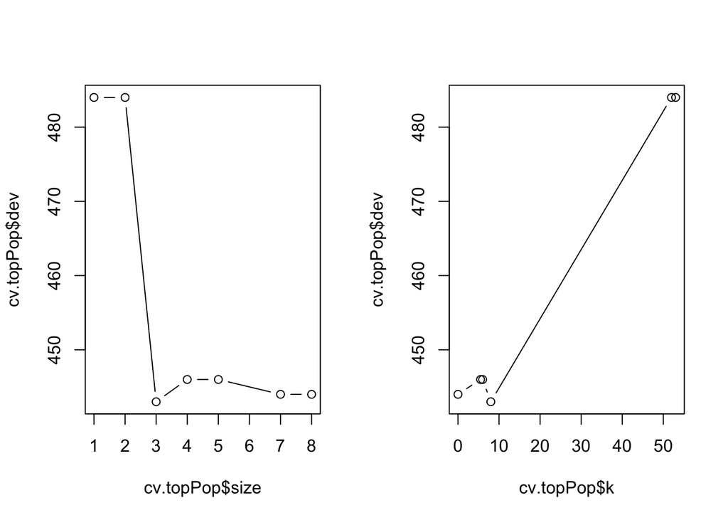

```r
par(mfrow = c(1, 2))
plot(cv.topPop$size, cv.topPop$dev, type = "b")
plot(cv.topPop$k, cv.topPop$dev, type = "b")
```

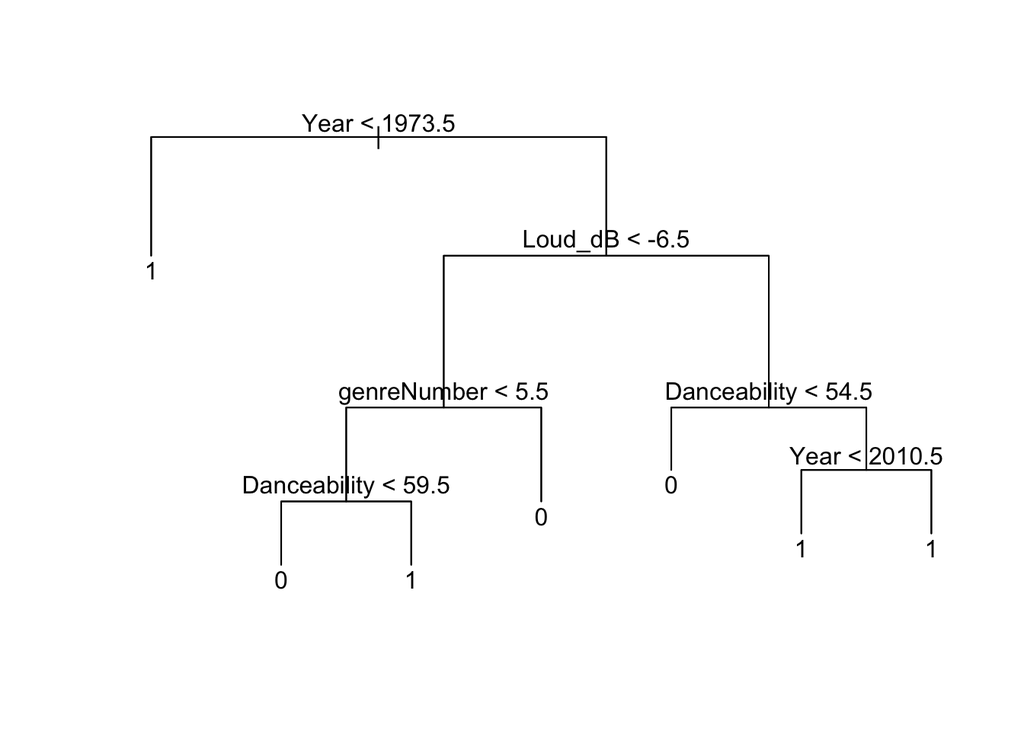

```r
prune.topPop <- prune.tree(tree.pop, best = 7)
plot(prune.topPop)
text(prune.topPop, pretty = 0)
```

```r
tart.time <- Sys.time()
tree.pred <- predict(prune.topPop, top.test, type = "class")
table(tree.pred, pop.test)
```

```
##          pop.test
## tree.pred   0   1
##         0 627 438
##         1 364 564
```

```r
end.time <- Sys.time()
time.taken <- end.time - start.time
time.taken
```

```
## Time difference of 0.1087801 secs
```

```r
(627 + 564)/(627 + 438 + 364 + 564)  ## accuracy
```

```
## [1] 0.5975916
```

```r
564/(438 + 564)  ## sensitivity
```

```
## [1] 0.5628743
```

```r
627/(627 + 364)  ## specificity
```

```
## [1] 0.6326942
```

Pruning doesn’t appear to produce better results than the default decision tree.

### Bagging

```r
library(randomForest)
set.seed(12)
start.time <- Sys.time()
bag.Pop <- randomForest(factor(groupedPopularity) ~ . -Index -groupedPopularity, data = spTop_Num, subset = train, mtry = 11, importance = TRUE)
bag.Pop
```

```
##
## Call:
##  randomForest(formula = factor(groupedPopularity) ~ . - Index -      groupedPopularity, data = spTop_Num, mtry = 11, importance = TRUE,      subset = train)
##                Type of random forest: classification
##                      Number of trees: 500
## No. of variables tried at each split: 11
##
##         OOB estimate of  error rate: 35.21%
## Confusion matrix:
##     0   1 class.error
## 0 353 161   0.3132296
## 1 190 293   0.3933747
```

```r
end.time <- Sys.time()
time.taken <- end.time - start.time
time.taken
```

```
## Time difference of 0.8445158 secs
```

```r
(353 + 293)/997
```

```
## [1] 0.6479438
```

Test set accuracy is 64.8%, with default of 500 trees.

#### Set number of trees to 25

```r
start.time <- Sys.time()
bag.pop <- randomForest(factor(groupedPopularity) ~ . -Index -groupedPopularity, data = spTop_Num, subset = train, mtry = 11, ntree = 25)
yhat.bag <- predict(bag.Pop, newdata = spTop_Num[-train, ])
conM.bag <- table(yhat.bag, pop.test)
end.time <- Sys.time()
time.taken <- end.time - start.time
time.taken
```

```
## Time difference of 0.136404 secs
```

```r
conM.bag
```

```
##         pop.test
## yhat.bag   0   1
##        0 742 176
##        1 249 826
```

#### Accuracy

```r
acc.bag <- (conM.bag[1,1] + conM.bag[2,2])/(conM.bag[1,1] + conM.bag[1,2] + conM.bag[2,1] + conM.bag[2,2])
acc.bag
```

```
## [1] 0.7867536
```

```r
se.bag <- 1 - acc.bag
se.bag
```

```
## [1] 0.2132464
```

#### Sensitivity and Specificity

```r
sen.bag <- conM.bag[2,2]/(conM.bag[1,2] + conM.bag[2,2])
sen.bag
```

```
## [1] 0.8243513
```

```r
spec.bag <- conM.bag[1,1]/(conM.bag[1,1] + conM.bag[2,1])
spec.bag
```

```
## [1] 0.7487386
```

### Random Forest

#### with sqrt(p) for classification - sqrt(11) = 3.32

```r
set.seed(12)

start.time <- Sys.time()
rf.pop <- randomForest(factor(groupedPopularity) ~ . -Index -groupedPopularity, data = spTop_Num, subset = train, mtry = 4, importance = TRUE)
yhat.rf <- predict(rf.pop, newdata = spTop_Num[-train, ])
table(yhat.rf, pop.test)
```

```
##        pop.test
## yhat.rf   0   1
##       0 752 182
##       1 239 820
```

```r
end.time <- Sys.time()
time.taken <- end.time - start.time
time.taken
```

```
## Time difference of 0.8384089 secs
```

```r
acc.RF <- (752 + 820)/(752 + 182 + 239 + 820)  ## accuracy
acc.RF
```

```
## [1] 0.7887607
```

```r
se.RF <- 1 - acc.RF
se.RF
```

```
## [1] 0.2112393
```

```r
sen.RF <- 820/(182 + 820)  ## sensitivity
sen.RF
```

```
## [1] 0.8183633
```

```r
spec.RF <- 752/(752 + 239)  ## specificity
spec.RF
```

```
## [1] 0.7588295
```

Test set accuracy is 78.9%, using Random Forest.

```r
importance(rf.pop)
```

```
##                       0          1 MeanDecreaseAccuracy MeanDecreaseGini
## Year          1.5528009 29.7296239            24.673100         55.86014
## BPM           0.8085682  6.6365584             5.213237         49.40566
## Energy        0.1752814  2.8898502             2.505817         46.81533
## Danceability  8.1509290 11.4285049            14.296796         58.46957
## Loud_dB       4.7302115 20.0185561            19.563753         42.93102
## Liveness      0.1898103  1.4599785             1.079448         41.98221
## Valence       7.2027790  0.4385914             6.373412         48.04543
## Duration      0.7524202  2.6973660             2.420132         51.08464
## Acousticness -1.1370628  7.7888330             4.915137         40.17787
## Speechiness   8.1592192  5.3289035             9.974815         28.32748
## genreNumber   3.2661664 20.3874861            17.428027         34.45096
```

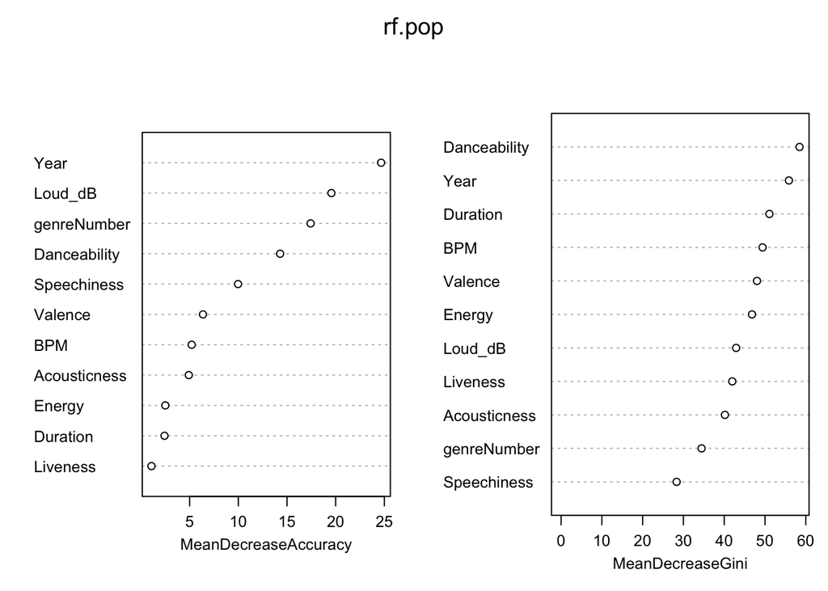

```r
varImpPlot(rf.pop, cex=0.8)
```

From the Variable Importance plot we see that the Year variable is the most important predictor and that Danceability may be an important predictor.

## Boosting

```r
set.seed(12)
train <- (spTop_Num$Index <= 997)
topPop.train <- spTop_Num[train, ]
topPop.test <- spTop_Num[-train, ]
```

```r
library(gbm)
set.seed(12)
start.time <- Sys.time()
boost.pop <- gbm(groupedPopularity ~ . -Index -groupedPopularity, data = topPop.train, n.trees = 1000, shrinkage = 0.01, distribution = "bernoulli")
boost.prob = predict(boost.pop, topPop.test, n.trees = 1000, type = "response")
boost.pred = ifelse(boost.prob > 0.2, 1, 0)
table(boost.pred, topPop.test$groupedPopularity)
```

```
##
## boost.pred    0    1
##          0   29    2
##          1  962 1000
```

```r
end.time <- Sys.time()
time.taken <- end.time - start.time
time.taken
```

```
## Time difference of 0.1352222 secs
```

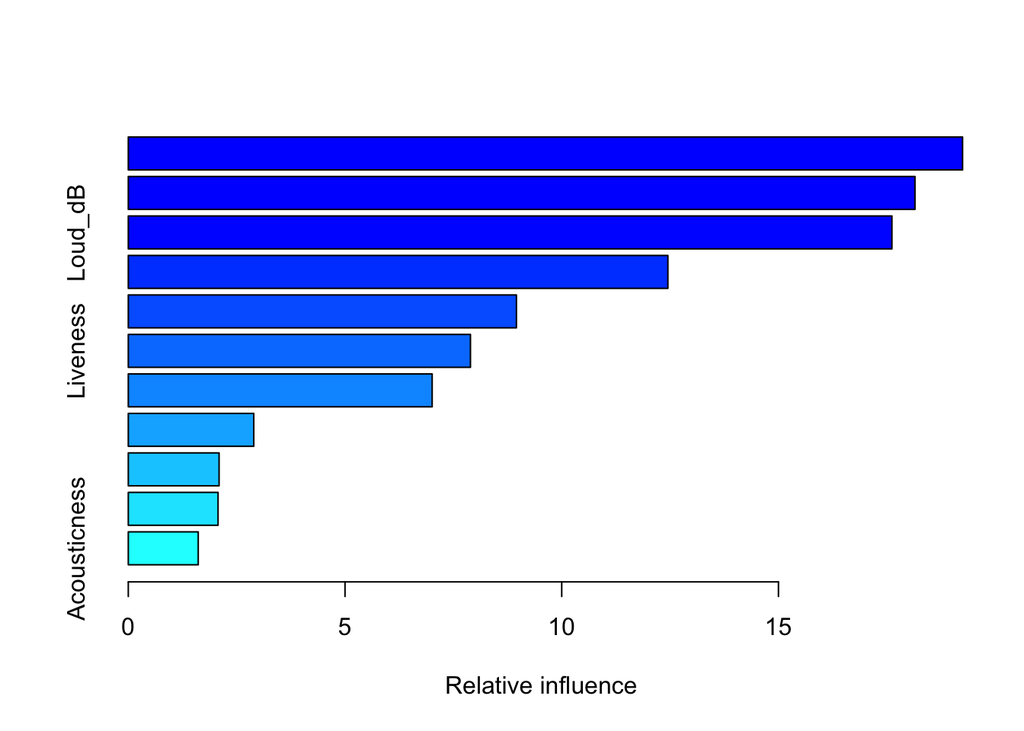

```
##                       var   rel.inf
## Year                 Year 19.247870
## Danceability Danceability 18.150101
## Loud_dB           Loud_dB 17.618374
## genreNumber   genreNumber 12.449698
## Duration         Duration  8.954744
## Liveness         Liveness  7.894001
## Speechiness   Speechiness  7.010718
## BPM                   BPM  2.894884
## Valence           Valence  2.094760
## Energy             Energy  2.071149
## Acousticness Acousticness  1.613701
```

```r
summary(boost.pop)
```

The Year, Loud_DB, and Danceability predictors appear to be the most important, we could may be also include genreNumber (the condensed genres categorized by numbers) as an important predictor as well.

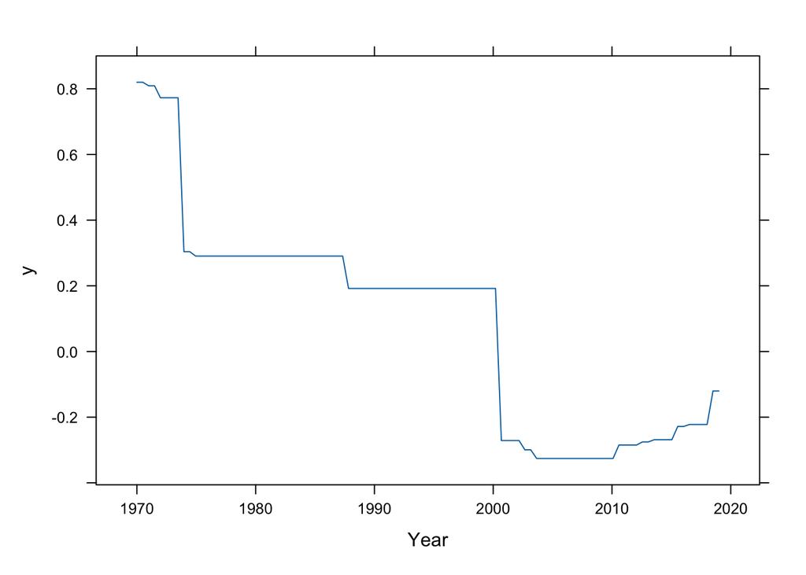

```r
plot(boost.pop, i = "Year")
```

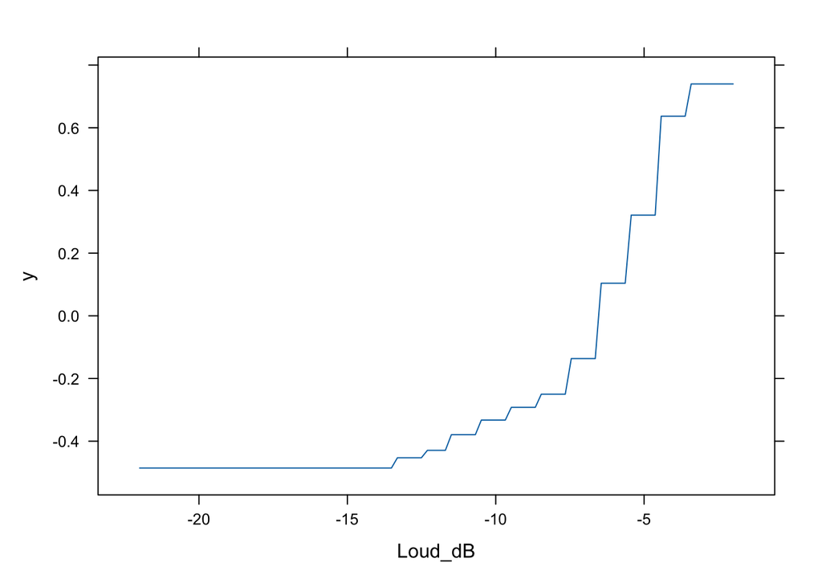

```r
plot(boost.pop, i = "Loud_dB")
```

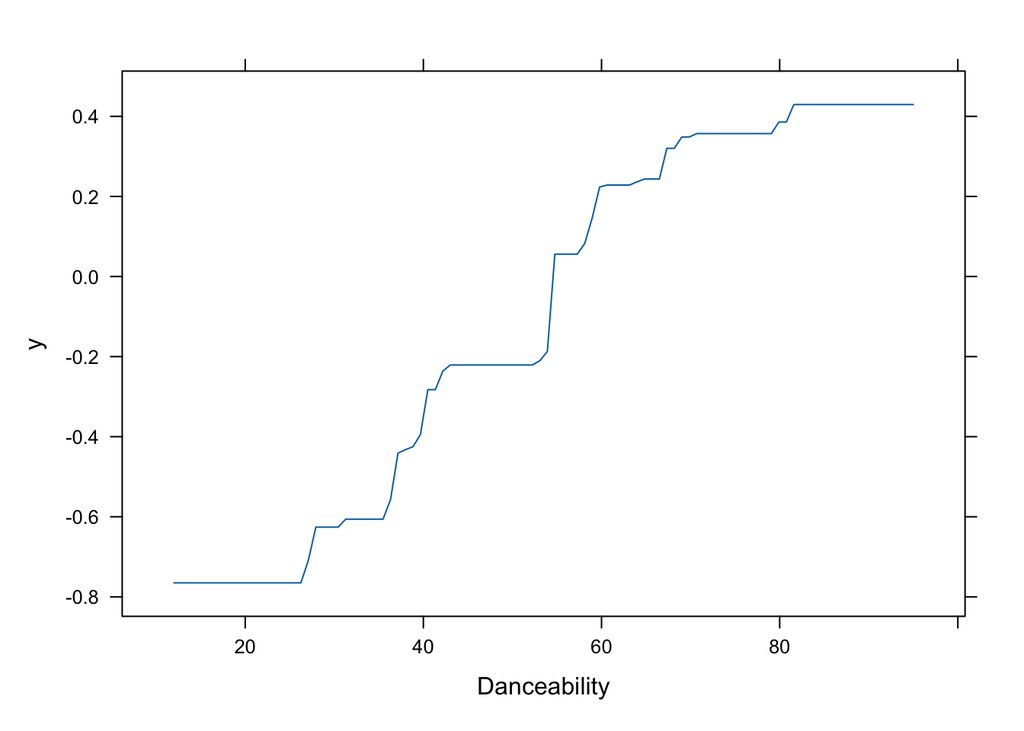

```r
plot(boost.pop, i = "Danceability")
```

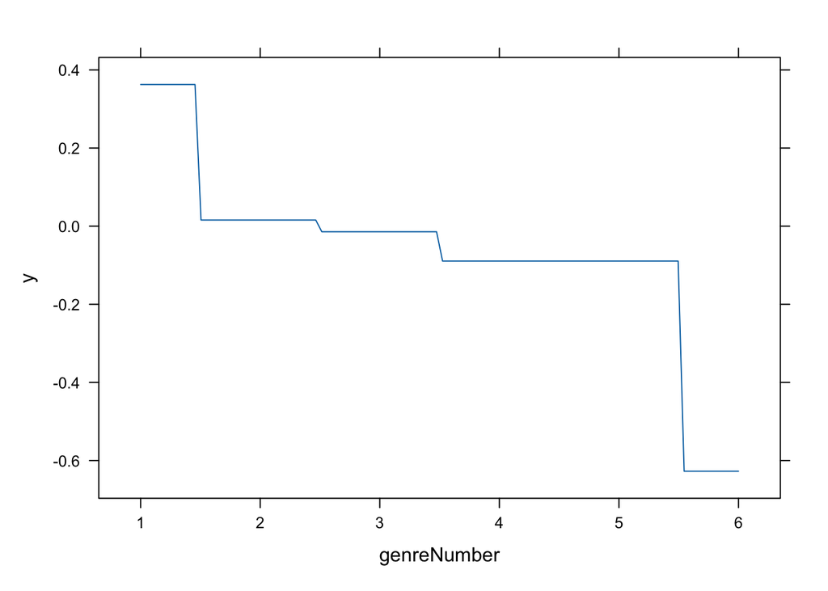

```r
plot(boost.pop, i = "genreNumber")
```

```r
conM.boost <- table(boost.pred, topPop.test$groupedPopularity)
conM.boost
```

```
##
## boost.pred    0    1
##          0   29    2
##          1  962 1000
```

```r
acc.boost <- (conM.boost[1,1] + conM.boost[2,2])/(conM.boost[1,1] + conM.boost[1,2] + conM.boost[2,1] + conM.boost[2,2])
acc.boost
```

```
## [1] 0.5163071
```

```r
se.boost <- 1 - acc.boost
se.boost
```

```
## [1] 0.4836929
```

```r
sen.boost <- conM.boost[2,2]/(conM.boost[1,2] + conM.boost[2,2])
sen.boost
```

```
## [1] 0.998004
```

```r
spec.boost <- conM.boost[1,1]/(conM.boost[1,1] + conM.boost[2,1])
spec.boost
```

```
## [1] 0.02926337
```

## Visualizations

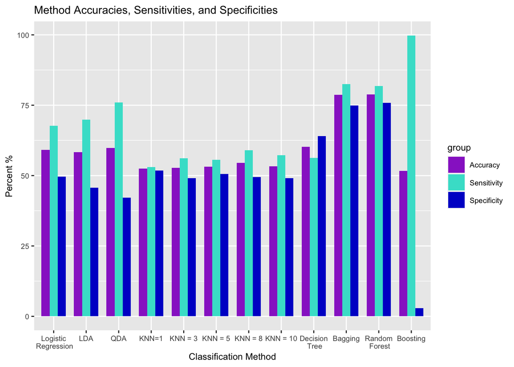

```r
acc <- data.frame(group = rep(c("Accuracy", "Sensitivity", "Specificity"), each=12),
                     mth = rep(c("Logistic\n Regression", "LDA", "QDA", "KNN=1", "KNN = 3", "KNN = 5", "KNN = 8", "KNN = 10", "Decision\n Tree", "Bagging",
                                 "Random\n Forest", "Boosting"), times=3),
                     prct = c(lr50.acc*100, lda50.acc*100, qda50.acc*100, knn1.acc50*100, knn3.acc50*100,  knn5.acc50*100, knn8.acc50*100, knn10.acc50*100,
                              acc.DT*100, acc.bag*100, acc.RF*100, acc.boost*100, lr50.sen*100, lda50.sen*100, qda50.sen*100, knn1.sen50*100, knn3.sen50*100,
                              knn5.sen50*100, knn8.sen50*100, knn10.sen50*100, sen.DT*100, sen.bag*100, sen.RF*100, sen.boost*100, lr50.spec*100,
                              lda50.spec*100, qda50.spec*100, knn1.spec50*100, knn3.spec50*100, knn5.spec50*100, knn8.spec50*100, knn10.spec50*100,
                              spec.DT*100, spec.bag*100, spec.RF*100, spec.boost*100))
acc$mth <- factor(acc$mth, levels = c("Logistic\n Regression", "LDA", "QDA", "KNN=1", "KNN = 3", "KNN = 5", "KNN = 8", "KNN = 10", "Decision\n Tree",
                                      "Bagging", "Random\n Forest", "Boosting"))
#acc.order
ggplot(acc, aes(x=mth, y=prct, fill=group)) + xlab("Classification Method") + ylab("Percent %") +
ggtitle("Method Accuracies, Sensitivities, and Specificities") +
  geom_bar(stat="identity", position = position_dodge(0.75), width = 0.75) + scale_fill_manual(values = c("#9932cc", "#40e0d0", "#0000cd")) +
  theme(text = element_text(size = 9))
```

## K-Fold Cross Validation - k = 5

### Five-Fold Cross-Validation

```r
names(spTop_Num)
```

```
##  [1] "Index"             "Year"              "BPM"
##  [4] "Energy"            "Danceability"      "Loud_dB"
##  [7] "Liveness"          "Valence"           "Duration"
## [10] "Acousticness"      "Speechiness"       "groupedPopularity"
## [13] "genreNumber"
```

```r
dim(spTop_Num)
```

```
## [1] 1994   13
```

```r
n=nrow(spTop_Num)
m=ncol(spTop_Num)
print(c(n,m))
```

```
## [1] 1994   13
```

```r
set.seed(12)
n_fold<-5;   ### number of cross validations
repeat.fold <- rep(1:n_fold, length.out = nrow(spTop_Num), options(max.print = 2000)) ### repeat 1:n_fold until we can see the full size of n
## repeat.fold
```

```r
folds_i <- sample(rep(1:n_fold, length.out = nrow(spTop_Num))) ## without replacement
table(folds_i)
```

```
## folds_i
##   1   2   3   4   5
## 399 399 399 399 398
```

#### 5-fold Cross-Validation for Logistic Regression Model - (manually)

```r
set.seed(12)
n_fold<-5; # number of cross validations #
folds_i <- sample(rep(1:n_fold, length.out = nrow(spTop_Num))) ##without replacement

start.time <- Sys.time()
OUT.glm=NULL
TRUTH = NULL; OUTPUT=NULL;
for (k in 1:n_fold)
{
  test.ID <- which(folds_i == k)
  train_set <- spTop_Num[-test.ID, ]  ## set up training set
  test_set <- spTop_Num[test.ID, ]  ## set up validation set

  glm.fit = glm(groupedPopularity ~ . -Index -groupedPopularity, data=train_set, family=binomial)  ### set up LR model
  glm.probs = predict(glm.fit, test_set, type="response")    ### get probabilities

  glm.pred = rep("0", length(test.ID))
  glm.pred[glm.probs>.5] = "1"
  table(glm.pred, test_set$groupedPopularity) ## confusion table

  Accuracy = mean(glm.pred == test_set$groupedPopularity) ## Prediction Accuracy
  OUT.glm = c(OUT.glm, Accuracy)

  TRUTH = c(TRUTH, test_set$groupedPopularity)
  OUTPUT = c(OUTPUT, glm.pred)
}
end.time <- Sys.time()
time.taken <- end.time - start.time
time.taken
```

```
## Time difference of 0.111001 secs
```

```r
print(OUT.glm)  ## print out the 5 accuracies found for 5-fold CV
```

```
## [1] 0.6115288 0.6015038 0.6766917 0.5939850 0.6231156
```

```r
mean(OUT.glm)   ## give the mean error for 5-fold CV
```

```
## [1] 0.621365
```

```r
sd(OUT.glm)     ## give the standard error for 5-fold CV
```

```
## [1] 0.03280624
```

#### Boxplot of 5-fold CV of LR model

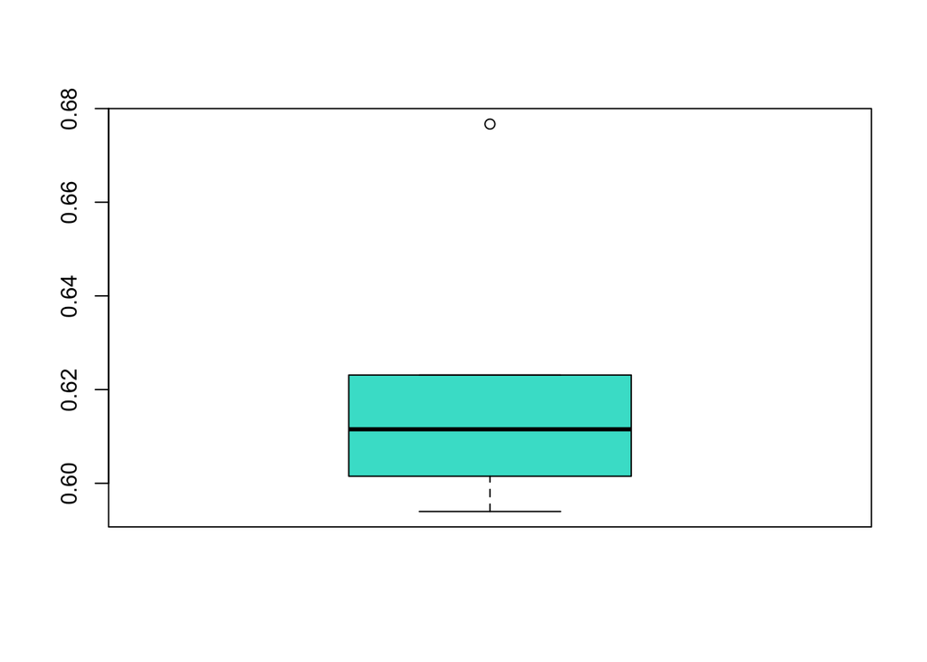

```r
boxplot(OUT.glm, col = "turquoise")
```

```r
contrasts(factor(TRUTH))  ### setting up for confusion matrix
```

```
##   1
## 0 0
## 1 1
```

```r
confusion = table(OUTPUT, TRUTH);
print(confusion)
```

```
##       TRUTH
## OUTPUT   0   1
##      0 611 375
##      1 380 628
```

```r
Overall.accuracy = sum(diag(confusion))/sum(confusion);
print(Overall.accuracy)
```

```
## [1] 0.6213641
```

```r
Overall.StError = 1 - Overall.accuracy;
print(Overall.StError)
```

```
## [1] 0.3786359
```

#### Find Sensitivity - 5-fold LR

```r
Sensitivity = confusion[2,2]/(confusion[1,2] + confusion[2,2]);
Sensitivity
```

```
## [1] 0.6261216
```

#### Find Specificity - 5-fold LR

```r
Specificity = confusion[1,1]/(confusion[1,1] + confusion[2,1]);
Specificity
```

```
## [1] 0.6165489
```

#### 5-fold CV for LDA using caret Package - (not manual method)

```r
install.packages("caret", repos = "http://cran.us.r-project.org") ## short for Classification And Regression Training
require(caret)
set.seed(12)
folds <- createFolds(groupedPopularity, k = 5, list = TRUE, returnTrain = FALSE)

start.time <- Sys.time()
OUT_LDA=NULL;
TRUTH_LDA = NULL; OUTPUT_LDA = NULL;
for (k in 1:n_fold)
{
  test.ID <- folds[[k]]
  train_set <- spTop_Num[-test.ID, ]
  test_set <- spTop_Num[test.ID, ]
  lda.fit = lda(groupedPopularity ~ . -Index -groupedPopularity, data = spTop_Num)
  lda.pred = predict(lda.fit, test_set[,c(1:11,13)])
  lda.class = lda.pred$class
  table(lda.class, test_set[,12])
  Accuracy = mean(lda.class == test_set[,12])
  OUT_LDA = c(OUT_LDA, Accuracy)

  TRUTH_LDA = c(TRUTH_LDA, test_set[,12])
  OUTPUT_LDA = c(OUTPUT_LDA, lda.class)
}
end.time <- Sys.time()
time.taken <- end.time - start.time
time.taken
```

```
## Time difference of 0.03316808 secs
```

```r
print(OUT_LDA)
```

```
## [1] 0.6090226 0.5889724 0.6516291 0.6231156 0.6641604
```

```r
print(mean(OUT_LDA))
```

```
## [1] 0.62738
```

```r
print(sd(OUT_LDA))
```

```
## [1] 0.0307048
```

#### Boxplot of 5-fold CV of LDA model

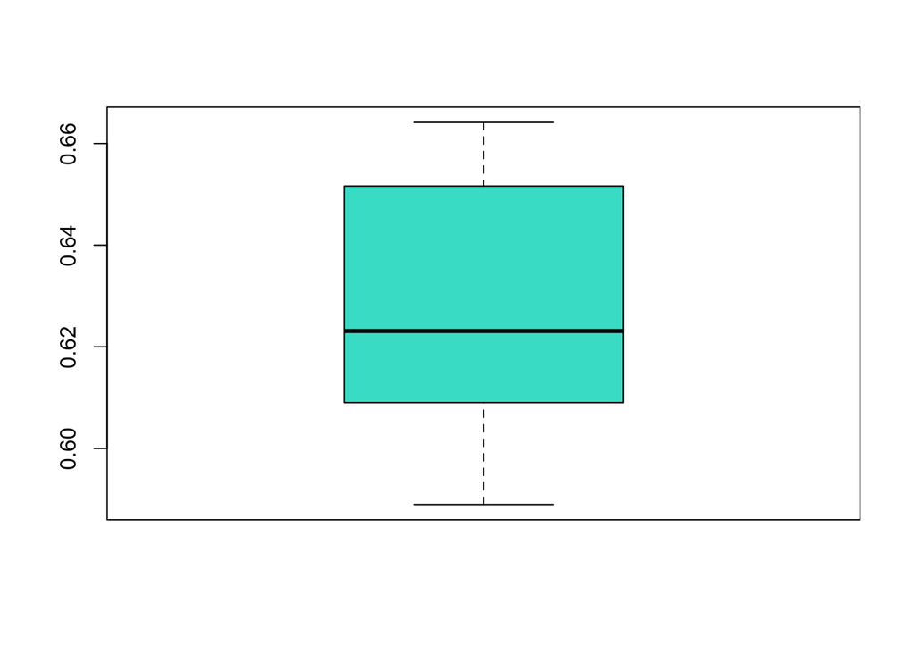

```r
boxplot(OUT_LDA, col="turquoise")
```

```r
contrasts(factor(TRUTH_LDA))  ### setting up for confusion matrix
```

```
##   1
## 0 0
## 1 1
```

```r
confusion_LDA = table(OUTPUT_LDA, TRUTH_LDA);
print(confusion_LDA)
```

```
##           TRUTH_LDA
## OUTPUT_LDA   0   1
##          1 616 368
##          2 375 635
```

```r
Overall.accuracy_LDA = sum(diag(confusion_LDA))/sum(confusion_LDA);
print(Overall.accuracy_LDA)
```

```
## [1] 0.6273821
```

```r
Overall.StError_LDA = 1 - Overall.accuracy_LDA;
print(Overall.StError_LDA)
```

```
## [1] 0.3726179
```

#### Find Sensitivity - 5-fold LDA

```r
Sensitivity_LDA = confusion_LDA[2,2]/(confusion_LDA[1,2] + confusion_LDA[2,2]);
Sensitivity_LDA
```

```
## [1] 0.6331007
```

#### Find Specificity - 5-fold LDA

```r
Specificity_LDA = confusion_LDA[1,1]/(confusion_LDA[1,1] + confusion_LDA[2,1]);
Specificity_LDA
```

```
## [1] 0.6215943
```

### 5-fold CV for QDA - (not manual)

```r
require(caret)
set.seed(12)
folds <- createFolds(groupedPopularity, k = 5, list = TRUE, returnTrain = FALSE)

start.time <- Sys.time()
OUT_QDA=NULL;
TRUTH_QDA = NULL; OUTPUT_QDA = NULL;
for (k in 1:n_fold)
{
  test.ID <- folds[[k]]
  train_set <- spTop_Num[-test.ID, ]
  test_set <- spTop_Num[test.ID, ]
  qda.fit = qda(groupedPopularity ~ . -Index -groupedPopularity, data = spTop_Num)
  qda.pred = predict(qda.fit, test_set[,c(1:11, 13)])
  qda.class = qda.pred$class
  table(qda.class,test_set[,12])
  Accuracy = mean(qda.class == test_set[,12])
  OUT_QDA = c(OUT_QDA, Accuracy)

  TRUTH_QDA = c(TRUTH_QDA, test_set[,12])
  OUTPUT_QDA = c(OUTPUT_QDA, qda.class)
}
end.time <- Sys.time()
time.taken <- end.time - start.time
time.taken
```

```
## Time difference of 0.02613187 secs
```

```r
print(OUT_QDA)
```

```
## [1] 0.6390977 0.6516291 0.6566416 0.6281407 0.6666667
```

```r
print(mean(OUT_QDA))
```

```
## [1] 0.6484352
```

```r
print(sd(OUT_QDA))
```

```
## [1] 0.01507471
```

#### Boxplot of 5-fold CV of QDA model

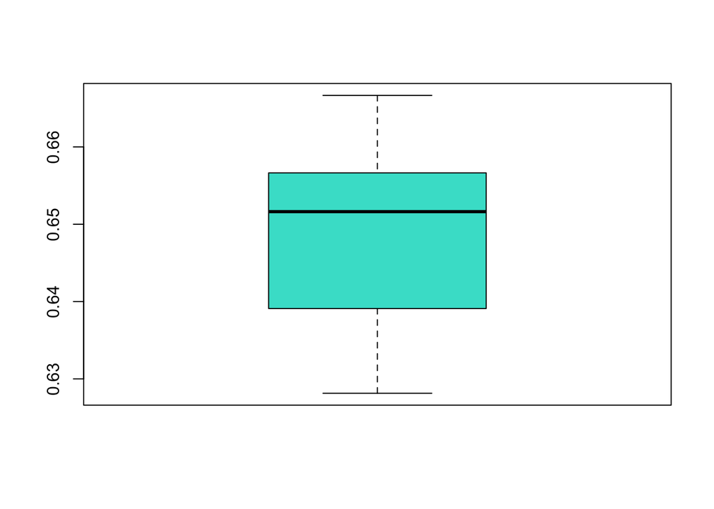

```r
boxplot(OUT_QDA, col="turquoise")
```

```r
contrasts(factor(TRUTH_QDA))  ### setting up for confusion matrix
```

```
##   1
## 0 0
## 1 1
```

```r
confusion_QDA = table(OUTPUT_QDA, TRUTH_QDA);
print(confusion_QDA)
```

```
##           TRUTH_QDA
## OUTPUT_QDA   0   1
##          1 577 287
##          2 414 716
```

```r
Overall.accuracy_QDA = sum(diag(confusion_QDA))/sum(confusion_QDA);
print(Overall.accuracy_QDA)
```

```
## [1] 0.6484453
```

```r
Overall.StError_QDA = 1 - Overall.accuracy_QDA;
print(Overall.StError_QDA)
```

```
## [1] 0.3515547
```

#### Find Sensitivity - 5-fold QDA

```r
Sensitivity_QDA = confusion_QDA[2,2]/(confusion_QDA[1,2] + confusion_QDA[2,2]);
Sensitivity_QDA
```

```
## [1] 0.7138584
```

#### Find Specificity - 5-fold QDA

```r
Specificity_QDA = confusion_QDA[1,1]/(confusion_QDA[1,1] + confusion_QDA[2,1]);
Specificity_QDA
```

```
## [1] 0.5822402
```

### 5-Fold CV for KNN

```r
set.seed(12)
n_fold<-5; # number of cross validations #
nrep <- rep(1:n_fold, length.out = nrow(spTop_Num)) ## repeat 1:n_fold until we can the full size of n
## nrep
```

```r
folds_i <- sample(rep(1:n_fold, length.out = nrow(spTop_Num))) ##without replacement
table(folds_i)
```

```
## folds_i
##   1   2   3   4   5
## 399 399 399 399 398
```

#### Find out which value of K has the highest accuracy

```r
Final.OUT = NULL
for (i in 1:10)
{
  OUT.KNN = NULL
  for (j in 1:n_fold)
    {
      test.ID <- which(folds_i == j)
      train_X <- spTop_Num[-test.ID, c(1:11, 13)]
      train_Y <- spTop_Num[-test.ID, 12]
      test_X <- spTop_Num[test.ID, c(1:11, 13)]
      test_Y <- spTop_Num[test.ID, 12]
      knn.pred=knn(train_X, test_X, train_Y, k=i)
      #table(knn.pred,test_Y)
      Accuracy = mean(knn.pred == test_Y)
      OUT.KNN = c(OUT.KNN, Accuracy)
  }
  print(c(i, OUT.KNN))
  Final.OUT = rbind(Final.OUT, OUT.KNN)
}
```

```
## [1] 1.0000000 0.5438596 0.5488722 0.5137845 0.5187970 0.5226131
## [1] 2.0000000 0.5764411 0.5839599 0.5488722 0.4937343 0.5201005
## [1] 3.0000000 0.5639098 0.5764411 0.5413534 0.5062657 0.5251256
## [1] 4.0000000 0.5513784 0.5764411 0.5062657 0.4937343 0.5351759
## [1] 5.0000000 0.5513784 0.5839599 0.5588972 0.5238095 0.5527638
## [1] 6.0000000 0.5538847 0.5939850 0.5664160 0.5388471 0.5427136
## [1] 7.0000000 0.5739348 0.6090226 0.5263158 0.5689223 0.5402010
## [1] 8.0000000 0.5714286 0.6040100 0.5313283 0.5363409 0.5603015
## [1] 9.0000000 0.5989975 0.5764411 0.5714286 0.5488722 0.5402010
## [1] 10.0000000  0.5764411  0.5889724  0.5714286  0.5538847  0.5552764
```

```r
apply(Final.OUT, 1, mean)
```

```
##   OUT.KNN   OUT.KNN   OUT.KNN   OUT.KNN   OUT.KNN   OUT.KNN   OUT.KNN   OUT.KNN
## 0.5295853 0.5446216 0.5426191 0.5325991 0.5541618 0.5591693 0.5636793 0.5606819
##   OUT.KNN   OUT.KNN
## 0.5671881 0.5692006
```

```r
rowMeans(Final.OUT)
```

```
##   OUT.KNN   OUT.KNN   OUT.KNN   OUT.KNN   OUT.KNN   OUT.KNN   OUT.KNN   OUT.KNN
## 0.5295853 0.5446216 0.5426191 0.5325991 0.5541618 0.5591693 0.5636793 0.5606819
##   OUT.KNN   OUT.KNN
## 0.5671881 0.5692006
```

```r
max(rowMeans(Final.OUT))
```

```
## [1] 0.5692006
```

We see that K = 10 produces the best accuracy.

## 5-fold CV for KNN = 10

```r
start.time <- Sys.time()
OUT.KNN.5fold = NULL
for (j in 1:n_fold)
{
  test.ID <- which(folds_i == j)
  train_X <- spTop_Num[-test.ID, c(1:11, 13)]
  train_Y <- spTop_Num[-test.ID, 12]
  test_X <- spTop_Num[test.ID, c(1:11, 13)]
  test_Y <- spTop_Num[test.ID, 12]
  knn.pred.5fold = knn(train_X, test_X, train_Y, k=10)
  table(knn.pred.5fold, test_Y)
  Accuracy = mean(knn.pred.5fold == test_Y)
  OUT.KNN.5fold = c(OUT.KNN.5fold, Accuracy)
}
end.time <- Sys.time()
time.taken <- end.time - start.time
time.taken
```

```
## Time difference of 0.05671716 secs
```

```r
print(OUT.KNN.5fold)
```

```
## [1] 0.5588972 0.5964912 0.5789474 0.5187970 0.5527638
```

```r
acc.KNN10.5fold <- mean(OUT.KNN.5fold) ## overall accuracy
acc.KNN10.5fold
```

```
## [1] 0.5611793
```

```r
se.KNN10.5fold <- 1 - acc.KNN10.5fold ## standard error
se.KNN10.5fold
```

```
## [1] 0.4388207
```

```r
Sensitivity_KNN10.5fold <- sensitivity(factor(knn.pred.5fold), factor(test_Y))
Sensitivity_KNN10.5fold
```

```
## [1] 0.520202
```

```r
Specificity_KNN10.5fold <- specificity(factor(knn.pred.5fold), factor(test_Y))
Specificity_KNN10.5fold
```

```
## [1] 0.585
```

```r
sd.KNN <- sd(OUT.KNN)
```

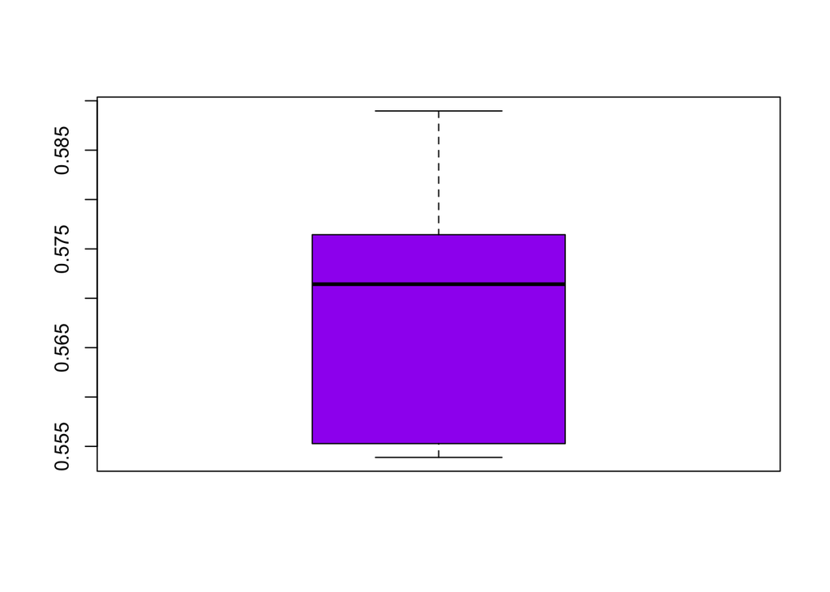

```r
KNN.5fold=OUT.KNN
boxplot(OUT.KNN,col="purple")
```

```r
conM.KNN10.5fold <- table(knn.pred, test_Y)
conM.KNN10.5fold
```

```
##         test_Y
## knn.pred   0   1
##        0 103  82
##        1  95 118
```

### 5-fold Cross Validation for Decision Tree

```r
require(caret)
set.seed(12)

start.time <- Sys.time()
folds <- createFolds(groupedPopularity, k = 5, list = TRUE, returnTrain = FALSE)

OUT_DT = NULL;
TRUTH_DT = NULL; OUTPUT_DT = NULL;
for (k in 1:n_fold)
{
  test.ID <- folds[[k]]
  train_set <- spTop_Num[-test.ID, ]
  test_set <- spTop_Num[test.ID, ]
  DT.fit =  tree(factor(groupedPopularity) ~ . -Index, data = spTop_Num, subset = -test.ID)
  DT.pred = predict(DT.fit, test_set[,c(1:11,13)], type = "class")
  grPop <- spTop_Num$groupedPopularity[test.ID]
  table(grPop,test_set[,12])
  Accuracy = mean(DT.pred == test_set[,12])
  OUT_DT = c(OUT_DT, Accuracy)

  TRUTH_DT = c(TRUTH_DT, test_set[,12])
  OUTPUT_DT = c(OUTPUT_DT, DT.pred)
}
end.time <- Sys.time()
time.taken <- end.time - start.time
time.taken
```

```
## Time difference of 0.03863406 secs
```

```r
print(OUT_DT)
```

```
## [1] 0.6040100 0.5814536 0.5839599 0.5954774 0.6140351
```

```r
print(mean(OUT_DT))
```

```
## [1] 0.5957872
```

```r
print(sd(OUT_DT))
```

```
## [1] 0.0136568
```

#### Boxplot of 5-fold CV of DT model

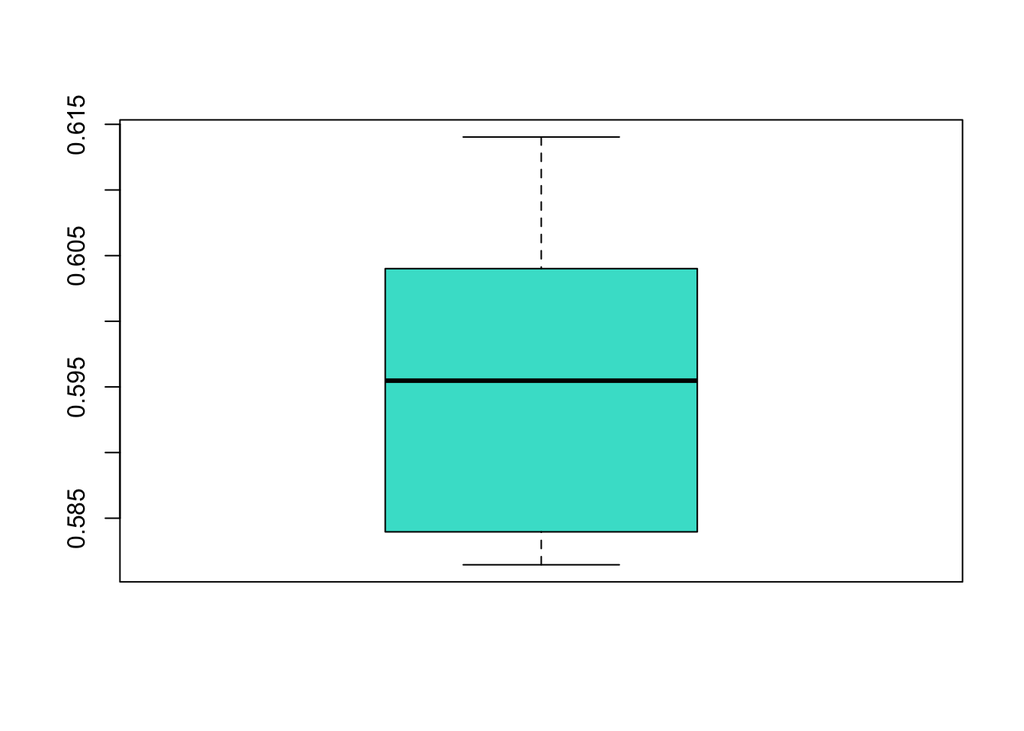

```r
boxplot(OUT_DT, col="turquoise")
```

```r
contrasts(factor(TRUTH_DT))  ### setting up for confusion matrix
```

```
##   1
## 0 0
## 1 1
```

```r
confusion_DT = table(OUTPUT_DT, TRUTH_DT);
print(confusion_DT)
```

```
##          TRUTH_DT
## OUTPUT_DT   0   1
##         1 684 499
##         2 307 504
```

```r
Overall.accuracy_DT = sum(diag(confusion_DT))/sum(confusion_DT);
print(Overall.accuracy_DT)
```

```
## [1] 0.5957874
```

```r
Overall.StError_DT = 1 - Overall.accuracy_DT;
print(Overall.StError_DT)
```

```
## [1] 0.4042126
```

#### Find Sensitivity - 5-fold DT

```r
Sensitivity_DT = confusion_DT[2,2]/(confusion_DT[1,2] + confusion_DT[2,2]);
Sensitivity_DT
```

```
## [1] 0.5024925
```

#### Find Specificity - 5-fold DT

```r
Specificity_DT = confusion_DT[1,1]/(confusion_DT[1,1] + confusion_DT[2,1]);
Specificity_DT
```

```
## [1] 0.6902119
```

### 5-fold CV for Bagging

```r
require(caret)
set.seed(12)

start.time <- Sys.time()
folds <- createFolds(groupedPopularity, k = 5, list = TRUE, returnTrain = FALSE)

OUT_bag = NULL;
TRUTH_bag = NULL; OUTPUT_bag = NULL;
for (k in 1:n_fold)
{
  test.ID <- folds[[k]]
  train_set <- spTop_Num[-test.ID, ]
  test_set <- spTop_Num[test.ID, ]
  bag.fit =  randomForest(factor(groupedPopularity) ~ . -Index, data = spTop_Num, subset = -test.ID, mtry = 11, ntree = 25)
  bag.pred = predict(bag.fit, test_set[,c(1:11,13)], type = "class")
  grPop <- spTop_Num$groupedPopularity[test.ID]
  table(grPop,test_set[,12])
  Accuracy = mean(bag.pred == test_set[,12])
  OUT_bag = c(OUT_bag, Accuracy)

  TRUTH_bag = c(TRUTH_bag, test_set[,12])
  OUTPUT_bag = c(OUTPUT_bag, bag.pred)
}
end.time <- Sys.time()
time.taken <- end.time - start.time
time.taken
```

```
## Time difference of 0.319216 secs
```

```r
print(OUT_bag)
```

```
## [1] 0.6165414 0.5939850 0.6140351 0.5904523 0.6240602
```

```r
print(mean(OUT_bag))
```

```
## [1] 0.6078148
```

```r
print(sd(OUT_bag))
```

```
## [1] 0.01476041
```

#### Boxplot of 5-fold CV of Bagging model

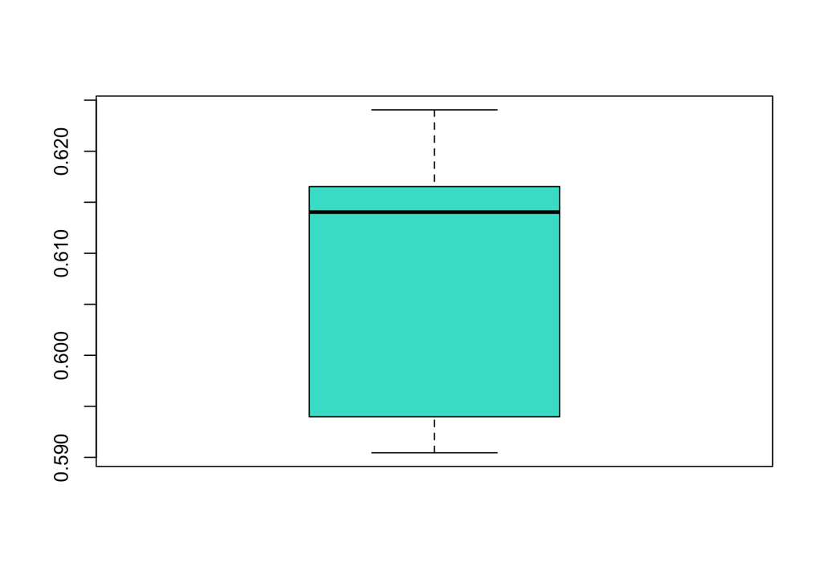

```r
boxplot(OUT_bag, col="turquoise")
```

```r
contrasts(factor(TRUTH_bag))  ### setting up for confusion matrix
```

```
##   1
## 0 0
## 1 1
```

```r
confusion_bag = table(OUTPUT_bag, TRUTH_bag);
print(confusion_bag)
```

```
##           TRUTH_bag
## OUTPUT_bag   0   1
##          1 601 392
##          2 390 611
```

```r
Overall.accuracy_bag = sum(diag(confusion_bag))/sum(confusion_bag);
print(Overall.accuracy_bag)
```

```
## [1] 0.6078235
```

```r
Overall.StError_bag = 1 - Overall.accuracy_bag;
print(Overall.StError_bag)
```

```
## [1] 0.3921765
```

#### Find Sensitivity - 5-fold Bagging

```r
Sensitivity_bag = confusion_bag[2,2]/(confusion_bag[1,2] + confusion_bag[2,2]);
Sensitivity_bag
```

```
## [1] 0.6091725
```

#### Find Specificity - 5-fold Bagging

```r
Specificity_bag = confusion_bag[1,1]/(confusion_bag[1,1] + confusion_bag[2,1]);
Specificity_bag
```

```
## [1] 0.6064581
```

### 5-fold CV for Random Forest

```r
require(caret)
set.seed(12)

start.time <- Sys.time()
folds <- createFolds(groupedPopularity, k = 5, list = TRUE, returnTrain = FALSE)

OUT_RF = NULL;
TRUTH_RF = NULL; OUTPUT_RF = NULL;
for (k in 1:n_fold)
{
  test.ID <- folds[[k]]
  train_set <- spTop_Num[-test.ID, ]
  test_set <- spTop_Num[test.ID, ]
  RF.fit =  randomForest(factor(groupedPopularity) ~ . -Index, data = spTop_Num, subset = -test.ID, mtry = 4, importance = TRUE)
  RF.pred = predict(RF.fit, test_set[,c(1:11,13)], type = "class")
  grPop <- spTop_Num$groupedPopularity[test.ID]
  table(grPop, test_set[,12])
  Accuracy = mean(RF.pred == test_set[,12])
  OUT_RF = c(OUT_RF, Accuracy)

  TRUTH_RF = c(TRUTH_RF, test_set[,12])
  OUTPUT_RF = c(OUTPUT_RF, RF.pred)
}
end.time <- Sys.time()
time.taken <- end.time - start.time
time.taken
```

```
## Time difference of 7.50451 secs
```

```r
print(OUT_RF)
```

```
## [1] 0.6390977 0.6591479 0.6416040 0.6155779 0.6566416
```

```r
print(mean(OUT_RF))
```

```
## [1] 0.6424138
```

```r
print(sd(OUT_RF))
```

```
## [1] 0.01742324
```

#### Boxplot of 5-fold CV of Random Forest model

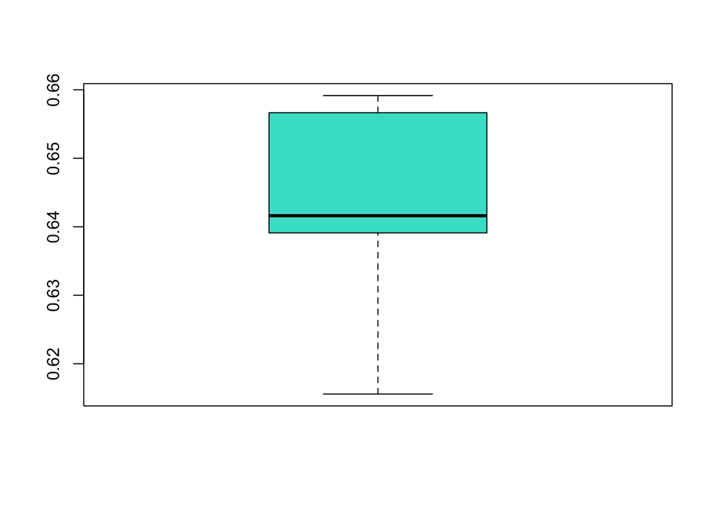

```r
boxplot(OUT_RF, col="turquoise")
```

```r
contrasts(factor(TRUTH_RF))  ### setting up for confusion matrix
```

```
##   1
## 0 0
## 1 1
```

```r
confusion_RF = table(OUTPUT_RF, TRUTH_RF);
print(confusion_RF)
```

```
##          TRUTH_RF
## OUTPUT_RF   0   1
##         1 644 366
##         2 347 637
```

```r
Overall.accuracy_RF = sum(diag(confusion_RF))/sum(confusion_RF);
print(Overall.accuracy_RF)
```

```
## [1] 0.6424273
```

```r
Overall.StError_RF = 1 - Overall.accuracy_RF;
print(Overall.StError_RF)
```

```
## [1] 0.3575727
```

#### Find Sensitivity - 5-fold Random Forest

```r
Sensitivity_RF = confusion_RF[2,2]/(confusion_RF[1,2] + confusion_RF[2,2]);
Sensitivity_RF
```

```
## [1] 0.6350947
```

#### Find Specificity - 5-fold Random Forest

```r
Specificity_RF = confusion_RF[1,1]/(confusion_RF[1,1] + confusion_RF[2,1]);
Specificity_RF
```

```
## [1] 0.6498486
```

### 5-fold Cross Validation for Boosting

```r
require(caret)
set.seed(12)

start.time <- Sys.time()
folds <- createFolds(groupedPopularity, k = 5, list = TRUE, returnTrain = FALSE)

OUT_boost = NULL;
TRUTH_boost = NULL; OUTPUT_boost = NULL;
for (k in 1:n_fold)
{
  test.ID <- folds[[k]]
  train_set <- spTop_Num[-test.ID, ]
  test_set <- spTop_Num[test.ID, ]
  boost.fit =  gbm(groupedPopularity ~ . -Index, data = spTop_Num, n.trees = 1000, shrinkage = 0.01, distribution = "bernoulli")
  boost.pred = predict(boost.fit, test_set[,c(1:11,13)], type = "response")
  boost.prediction <- ifelse(boost.pred >= .5, 1, 0)
  grPop <- spTop_Num$groupedPopularity[test.ID]
  table(grPop, test_set[,12])
  Accuracy = mean(boost.prediction == test_set[,12])
  OUT_boost = c(OUT_boost, Accuracy)

  TRUTH_boost = c(TRUTH_boost, test_set[,12])
  OUTPUT_boost = c(OUTPUT_boost, boost.prediction)
}
```

```
## Using 1000 trees...
##
## Using 1000 trees...
##
## Using 1000 trees...
##
## Using 1000 trees...
##
## Using 1000 trees...
```

```r
end.time <- Sys.time()
time.taken <- end.time - start.time
time.taken
```

```
## Time difference of 1.166901 secs
```

```r
print(OUT_boost)
```

```
## [1] 0.6541353 0.6416040 0.6491228 0.6331658 0.6942356
```

```r
print(mean(OUT_boost))
```

```
## [1] 0.6544527
```

```r
print(sd(OUT_boost))
```

```
## [1] 0.0236083
```

#### Boxplot of 5-fold CV of Boosting

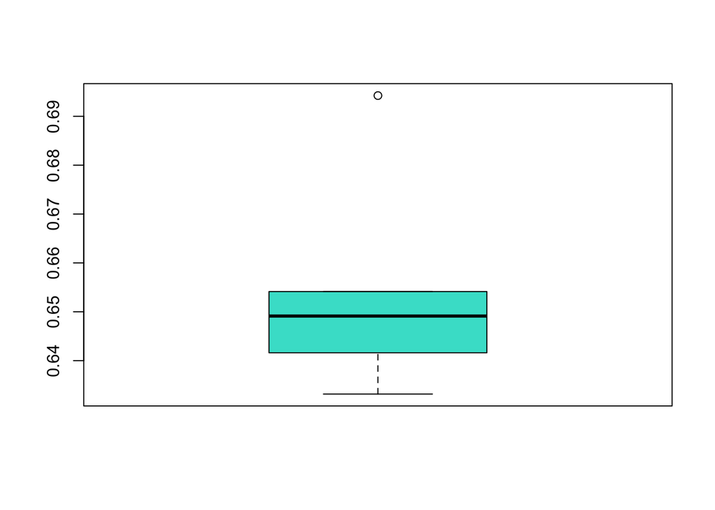

```r
boxplot(OUT_boost, col="turquoise")
```

```r
contrasts(factor(TRUTH_boost))  ### setting up for confusion matrix
```

```
##   1
## 0 0
## 1 1
```

```r
confusion_boost = table(OUTPUT_boost, TRUTH_boost);
print(confusion_boost)
```

```
##             TRUTH_boost
## OUTPUT_boost   0   1
##            0 652 350
##            1 339 653
```

```r
Overall.accuracy_boost = sum(diag(confusion_boost))/sum(confusion_boost);
print(Overall.accuracy_boost)
```

```
## [1] 0.6544634
```

```r
Overall.StError_boost = 1 - Overall.accuracy_boost;
print(Overall.StError_boost)
```

```
## [1] 0.3455366
```

#### Find Sensitivity - 5-fold Boosting

```r
Sensitivity_boost = confusion_boost[2,2]/(confusion_boost[1,2] + confusion_boost[2,2]);
Sensitivity_boost
```

```
## [1] 0.6510469
```

#### Find Specificity - 5-fold Boosting

```r
Specificity_boost = confusion_boost[1,1]/(confusion_boost[1,1] + confusion_boost[2,1]);
Specificity_boost
```

```
## [1] 0.6579213
```